# I. Introduction

#### c. with Elastic Net, in sliding window instead of expanding window

```python
# Pipeline function
def pipeline(config):
    alpha, l1_ratio = config
    steps = [
        ('scaler', StandardScaler(copy=True, with_mean=True, with_std=True)),
        ('pca', PCA(n_components=3, random_state=1)), # As observed, 3 to save time
        ('elastic_net', ElasticNet(alpha=alpha, l1_ratio=l1_ratio, random_state=1))
    ]
    return Pipeline(steps)

# Sliding window walk-forward validation
def walk_forward_validation(cfg, window_size=120):  # window_size of 120 means 10 years if monthly data
    n_trains = n_train
    n_records = n_train + n_valid
    y_test_list = []
    y_pred_list = []
    for i in range(n_trains, n_records):
        start = max(0, i - window_size)
        X_train, X_test = X[start:i], X[i:i+1]
        y_train, y_test = y[start:i], y[i:i+1]
        model = pipeline(cfg).fit(X_train, y_train)
        y_pred = model.predict(X_test)
        y_pred_list.extend(y_pred)
        y_test_list.extend(y_test)
    score_rmse = metrics.mean_squared_error(y_test_list, y_pred_list, squared=False)
    return score_rmse

# Repeat evaluation
def repeat_evaluate(config, n_repeats=1):
    key = str(config)
    scores = [walk_forward_validation(config) for _ in range(n_repeats)]
    result = np.mean(scores)
    print(f'> Model[{key}] {result:.3f}')
    return (key, result)

# Grid search
def grid_search(cfg_list):
    scores = [repeat_evaluate(cfg) for cfg in cfg_list]
    scores.sort(key=lambda tup: tup[1])
    return scores

# Model configurations
def model_configs():
    alphas = [0.0001, 0.001, 0.01, 0.1, 1, 10, 100]
    l1_ratios = [0, 0.1, 0.5, 0.9, 1]
    configs = [(alpha, l1_ratio) for alpha in alphas for l1_ratio in l1_ratios]
    print(f'Total configs: {len(configs)}')
    return configs
```

```python
# Run grid search
cfg_list = model_configs()
scores = grid_search(cfg_list)
print('Grid search completed')

# Print results
for config, score in scores:
    print(f'Config: {config}, RMSE: {score:.3f}')
```

```
Total configs: 35
> Model[(0.0001, 0)] 0.052
> Model[(0.0001, 0.1)] 0.052
> Model[(0.0001, 0.5)] 0.052
> Model[(0.0001, 0.9)] 0.052
> Model[(0.0001, 1)] 0.052
> Model[(0.001, 0)] 0.052
> Model[(0.001, 0.1)] 0.052
> Model[(0.001, 0.5)] 0.052
> Model[(0.001, 0.9)] 0.052
> Model[(0.001, 1)] 0.052
> Model[(0.01, 0)] 0.052
> Model[(0.01, 0.1)] 0.052
> Model[(0.01, 0.5)] 0.051
> Model[(0.01, 0.9)] 0.050
> Model[(0.01, 1)] 0.050
> Model[(0.1, 0)] 0.052
> Model[(0.1, 0.1)] 0.050
> Model[(0.1, 0.5)] 0.043
> Model[(0.1, 0.9)] 0.037
> Model[(0.1, 1)] 0.036
> Model[(1, 0)] 0.049
> Model[(1, 0.1)] 0.036
> Model[(1, 0.5)] 0.038
> Model[(1, 0.9)] 0.038
> Model[(1, 1)] 0.038
> Model[(10, 0)] 0.037
> Model[(10, 0.1)] 0.038
> Model[(10, 0.5)] 0.038
> Model[(10, 0.9)] 0.038
> Model[(10, 1)] 0.038
> Model[(100, 0)] 0.035
> Model[(100, 0.1)] 0.038
> Model[(100, 0.5)] 0.038
> Model[(100, 0.9)] 0.038
> Model[(100, 1)] 0.038
Grid search completed
Config: (100, 0), RMSE: 0.035
Config: (1, 0.1), RMSE: 0.036
Config: (0.1, 1), RMSE: 0.036
```

[output cut: 17 more lines]

```
Config: (0.01, 0.9), RMSE: 0.050
Config: (0.01, 0.5), RMSE: 0.051
Config: (0.1, 0), RMSE: 0.052
Config: (0.01, 0.1), RMSE: 0.052
Config: (0.001, 1), RMSE: 0.052
Config: (0.001, 0.9), RMSE: 0.052
Config: (0.001, 0.5), RMSE: 0.052
Config: (0.01, 0), RMSE: 0.052
Config: (0.001, 0.1), RMSE: 0.052
Config: (0.0001, 1), RMSE: 0.052
Config: (0.0001, 0.9), RMSE: 0.052
Config: (0.0001, 0.5), RMSE: 0.052
Config: (0.001, 0), RMSE: 0.052
Config: (0.0001, 0.1), RMSE: 0.052
Config: (0.0001, 0), RMSE: 0.052
```

```python
# Select best model
best_config = min(scores, key=lambda x: x[1])[0]
best_alpha, best_l1_ratio = eval(best_config)
print(f"Best config: alpha={best_alpha}, l1_ratio={best_l1_ratio}")
```

```
Best config: alpha=100, l1_ratio=0
```

```python
# Final evaluation with sliding window
pipeline_final = pipeline((best_alpha, best_l1_ratio))
n_trains = n_train + n_valid
n_records = n_train + n_valid + n_test
y_test_list = []
y_pred_list = []
window_size = 120  # 10 years for monthly data

start = time.time()
for i in range(n_trains, n_records):
    start_idx = max(0, i - window_size)
    X_train, X_test = X[start_idx:i], X[i:i+1]
    y_train, y_test = y[start_idx:i], y[i:i+1]
    model = pipeline_final.fit(X_train, y_train)
    y_pred = model.predict(X_test)
    y_pred_list.extend(y_pred)
    y_test_list.extend(y_test)
end = time.time()

olspca_en_sw_time = end-start
print(f"Running Time: {olspca_en_sw_time:.4f} seconds")
```

```
Running Time: 1.3765 seconds
```

```python
# Calculate metrics
olspca_en_sw_mse = metrics.mean_squared_error(y_test_list, y_pred_list, squared=False)
olspca_en_sw_r2 = metrics.r2_score(y_test_list, y_pred_list)
print(f"Test RMSE: {olspca_en_sw_mse:.4f}")
print(f"Test R-squared: {olspca_en_sw_r2:.4f}")
```

```
Test RMSE: 0.2217
Test R-squared: -0.0729
```

```python
pd.options.display.max_rows=300
result = pd.DataFrame({'IR_growth_Actual': y[-n_test:], 'IR_growth_Predicted': y_pred_list}, columns=['IR_growth_Actual', 'IR_growth_Predicted'])
result
```

| sasdate | IR_growth_Actual | IR_growth_Predicted |
| --- | --- | --- |
| 2016-11-01 | 0.01 | -0.041941 |
| 2016-12-01 | 0.13 | -0.040852 |
| 2017-01-01 | 0.11 | -0.029349 |
| 2017-02-01 | 0.01 | -0.037228 |
| 2017-03-01 | 0.13 | -0.039878 |
| 2017-04-01 | 0.11 | -0.035918 |
| 2017-05-01 | 0.01 | -0.026770 |
| 2017-06-01 | 0.13 | -0.038772 |
| 2017-07-01 | 0.11 | -0.030252 |
| 2017-08-01 | 0.01 | -0.037375 |
| 2017-09-01 | -0.01 | -0.032016 |
| 2017-10-01 | 0.00 | -0.026047 |
| 2017-11-01 | 0.01 | -0.024060 |
| 2017-12-01 | 0.14 | -0.022377 |
| 2018-01-01 | 0.11 | -0.019534 |
| 2018-02-01 | 0.01 | -0.015760 |
| 2018-03-01 | 0.09 | -0.004362 |
| 2018-04-01 | 0.18 | -0.004990 |
| 2018-05-01 | 0.01 | 0.003119 |
| 2018-06-01 | 0.12 | 0.001335 |
| 2018-07-01 | 0.09 | 0.002193 |
| 2018-08-01 | 0.00 | 0.003554 |
| 2018-09-01 | 0.04 | 0.007038 |
| 2018-10-01 | 0.24 | 0.006634 |
| 2018-11-01 | 0.01 | 0.014238 |
| 2018-12-01 | 0.07 | 0.017544 |
| 2019-01-01 | 0.13 | 0.020609 |
| 2019-02-01 | 0.00 | 0.023066 |
| 2019-03-01 | 0.01 | 0.020042 |
| 2019-04-01 | 0.01 | 0.021061 |
| 2019-05-01 | -0.03 | 0.023103 |
| 2019-06-01 | -0.01 | 0.021781 |
| 2019-07-01 | 0.02 | 0.017957 |
| 2019-08-01 | -0.27 | 0.018860 |
| 2019-09-01 | -0.09 | 0.017407 |
| 2019-10-01 | -0.21 | 0.015941 |
| 2019-11-01 | -0.28 | 0.010383 |
| 2019-12-01 | 0.00 | 0.015064 |
| 2020-01-01 | 0.00 | 0.010144 |
| 2020-02-01 | 0.03 | 0.011540 |
| 2020-03-01 | -0.93 | 0.013116 |
| 2020-04-01 | -0.60 | -0.051572 |
| 2020-05-01 | 0.00 | -0.405174 |
| 2020-06-01 | 0.03 | 0.023037 |
| 2020-07-01 | 0.01 | 0.018437 |
| 2020-08-01 | 0.01 | 0.007186 |
| 2020-09-01 | -0.01 | 0.001203 |
| 2020-10-01 | 0.00 | -0.002690 |
| 2020-11-01 | 0.00 | -0.001130 |
| 2020-12-01 | 0.00 | -0.001277 |
| 2021-01-01 | 0.00 | 0.001916 |
| 2021-02-01 | -0.01 | -0.002416 |
| 2021-03-01 | -0.01 | -0.002600 |
| 2021-04-01 | 0.00 | 0.002155 |
| 2021-05-01 | -0.01 | 0.001231 |
| 2021-06-01 | 0.02 | 0.000186 |
| 2021-07-01 | 0.02 | 0.000028 |
| 2021-08-01 | -0.01 | -0.002909 |
| 2021-09-01 | -0.01 | -0.002593 |
| 2021-10-01 | 0.00 | -0.002376 |
| 2021-11-01 | 0.00 | 0.002210 |
| 2021-12-01 | 0.00 | -0.002673 |
| 2022-01-01 | 0.00 | -0.005235 |
| 2022-02-01 | 0.00 | -0.001292 |
| 2022-03-01 | 0.12 | -0.000143 |
| 2022-04-01 | 0.13 | 0.000122 |
| 2022-05-01 | 0.44 | -0.000971 |
| 2022-06-01 | 0.44 | 0.009548 |
| 2022-07-01 | 0.47 | 0.017972 |
| 2022-08-01 | 0.65 | 0.014370 |
| 2022-09-01 | 0.23 | 0.024668 |
| 2022-10-01 | 0.52 | 0.035593 |
| 2022-11-01 | 0.70 | 0.042741 |
| 2022-12-01 | 0.32 | 0.039684 |
| 2023-01-01 | 0.23 | 0.036138 |
| 2023-02-01 | 0.24 | 0.040495 |
| 2023-03-01 | 0.08 | 0.046163 |
| 2023-04-01 | 0.18 | 0.042049 |

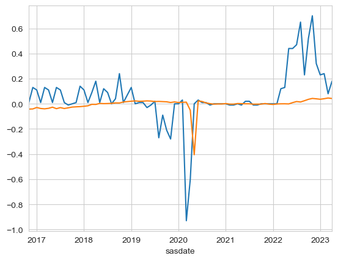

```python
result['IR_growth_Actual'].plot(label='Actual')
result['IR_growth_Predicted'].plot(label='Preducted')
```

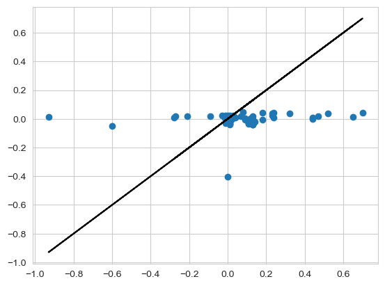

```python
plt.scatter(y_test_list, y_pred_list)
plt.plot(y_test_list, y_test_list,'k-') # identity line
```

```python
model = "OLS with PCA in EN Reg. in S.W."
r_square = olspca_en_sw_r2
mse = olspca_en_sw_mse
time = olspca_en_sw_time

olspca_en_sw_results = {
                    'Model': model,
                    'R-Squared': r_square,
                    'MSE': mse,
                    'Time': time
                  }
```

```python
final_results = pd.concat([final_results, pd.DataFrame([olspca_en_sw_results])], ignore_index=True)
final_results
```

|  | Model | R-Squared | MSE | Time |
| --- | --- | --- | --- | --- |
| 0 | OLS | -6.845652 | 0.603126 | 2.325707 |
| 1 | OLS with PCA | -10.952001 | 0.739855 | 0.660926 |
| 2 | OLS with PCA in EN Reg. | -0.072702 | 0.221649 | 2.587655 |
| 3 | OLS with PCA in EN Reg. in S.W. | -0.072877 | 0.221667 | 1.376456 |

### C. Baseline model with RFE

#### a. without regularisation

```python
# pipeline
def pipeline(config):

    # unpack config
    n_features = config

    # Steps
    steps = [('scaler', StandardScaler(copy=True, with_mean=True, with_std=True)),
             ('rfe', RFE(LinearRegression(), n_features_to_select=n_features)),
             ('ols', LinearRegression())
            ]

    pipeline = Pipeline(steps)

    return pipeline
```

```python
def walk_forward_validation(cfg):

    n_trains = n_train

    n_records = n_train + n_valid

    y_test_list = []

    y_pred_list = []

    j = 0

    for i in range(n_trains, n_records):

        X_train, X_test, y_train, y_test = X[j:i], X[i:i+1], y[j:i], y[i:i+1]

        model = pipeline(cfg).fit(X_train, y_train)

        y_pred = model.predict(X_test)

        y_pred_list.extend(y_pred)

        y_test_list.extend(y_test)

        j += 1

    score_rmse = metrics.mean_squared_error(y_test_list, y_pred_list, squared=False)

    print(' > %.3f' % score_rmse)

    return score_rmse
```

```python
# score a model, return None on failure
def repeat_evaluate(config, n_repeats=1):
    # convert config to a key
    key = str(config)
    # fit and evaluate the model n times
    scores = [walk_forward_validation(config) for _ in range(n_repeats)]
    # summarize score
    result = np.mean(scores)
    print('> Model[%s] %.3f' % (key, result))
    return (key, result)
```

```python
# grid search configs
def grid_search(cfg_list):
    # evaluate configs
    scores = [repeat_evaluate(cfg) for cfg in cfg_list]
    # sort configs by score_rmse, asc
    #scores.sort(key=lambda tup: tup[1])
    scores.sort(key=lambda tup: tup[1], reverse=True)
    return scores
```

```python
# create a list of configs to try
def model_configs():

    # define scope of configs
    n_features = [5,6,7,8,9,10,15,20,25,30]

    # create configs
    configs = list()

    for k in n_features:
        cfg = k
        configs.append(cfg)

    print('Total configs: %d' % len(configs))
    return configs
```

```python
# model configs
cfg_list = model_configs()
```

```
Total configs: 10
```

```python
cfg_list = model_configs()
# grid search
scores = grid_search(cfg_list)
print('done')
```

```
Total configs: 10
 > 0.154
> Model[5] 0.154
 > 0.155
> Model[6] 0.155
 > 0.156
> Model[7] 0.156
 > 0.151
> Model[8] 0.151
 > 0.142
> Model[9] 0.142
 > 0.103
> Model[10] 0.103
 > 0.113
> Model[15] 0.113
 > 0.143
> Model[20] 0.143
 > 0.149
> Model[25] 0.149
 > 0.157
> Model[30] 0.157
done
```

```python
scores
```

```
[('30', 0.15694076253907022),
 ('7', 0.15574880546117872),
 ('6', 0.15455661169464552),
 ('5', 0.15427998822294064),
 ('8', 0.15146227439335483),
 ('25', 0.14892901173826223),
 ('20', 0.14339102460259712),
 ('9', 0.14207862944332283),
 ('15', 0.11330012078918111),
 ('10', 0.102802460671657)]
```

```python
# Pipeline

# Steps
steps_final = [('scaler', StandardScaler(copy=True, with_mean=True, with_std=True)),
               ('rfe', RFE(LinearRegression(), n_features_to_select=10)),
               ('ols', LinearRegression())
              ]

pipeline_final = Pipeline(steps_final)
```

```python
start=time.time()

n_trains = n_train + n_valid

n_records = n_train + n_valid + n_test

y_test_list = []

y_pred_list = []

j = 0

for i in range(n_trains, n_records):

    X_train, X_test, y_train, y_test = X[j:i], X[i:i+1], y[j:i], y[i:i+1]

    model = pipeline_final.fit(X_train, y_train)

    y_pred = model.predict(X_test)

    y_pred_list.extend(y_pred)

    y_test_list.extend(y_test)

    j += 1

end=time.time()

olsrfe_time = end-start
print("Running Time:", olsrfe_time)
```

```
Running Time: 106.5129988193512
```

```python
pd.options.display.max_rows=300
result = pd.DataFrame({'IR_growth_Actual': y[-n_test:], 'IR_growth_Predicted': y_pred_list}, columns=['IR_growth_Actual', 'IR_growth_Predicted'])
result
```

| sasdate | IR_growth_Actual | IR_growth_Predicted |
| --- | --- | --- |
| 2016-11-01 | 0.01 | 0.072215 |
| 2016-12-01 | 0.13 | -0.039185 |
| 2017-01-01 | 0.11 | 0.070910 |
| 2017-02-01 | 0.01 | 0.032165 |
| 2017-03-01 | 0.13 | -0.128353 |
| 2017-04-01 | 0.11 | 0.203672 |
| 2017-05-01 | 0.01 | -0.049169 |
| 2017-06-01 | 0.13 | 0.094052 |
| 2017-07-01 | 0.11 | 0.070181 |
| 2017-08-01 | 0.01 | -0.073129 |
| 2017-09-01 | -0.01 | 0.132233 |
| 2017-10-01 | 0.00 | 0.103319 |
| 2017-11-01 | 0.01 | 0.104231 |
| 2017-12-01 | 0.14 | 0.191854 |
| 2018-01-01 | 0.11 | 0.113969 |
| 2018-02-01 | 0.01 | 0.126538 |
| 2018-03-01 | 0.09 | 0.134199 |
| 2018-04-01 | 0.18 | 0.195129 |
| 2018-05-01 | 0.01 | 0.104908 |
| 2018-06-01 | 0.12 | 0.048926 |
| 2018-07-01 | 0.09 | 0.126431 |
| 2018-08-01 | 0.00 | 0.072638 |
| 2018-09-01 | 0.04 | 0.039324 |
| 2018-10-01 | 0.24 | 0.107592 |
| 2018-11-01 | 0.01 | 0.136435 |
| 2018-12-01 | 0.07 | 0.087814 |
| 2019-01-01 | 0.13 | 0.043943 |
| 2019-02-01 | 0.00 | 0.091649 |
| 2019-03-01 | 0.01 | -0.002993 |
| 2019-04-01 | 0.01 | -0.082174 |
| 2019-05-01 | -0.03 | -0.056550 |
| 2019-06-01 | -0.01 | -0.142970 |
| 2019-07-01 | 0.02 | -0.226395 |
| 2019-08-01 | -0.27 | -0.003001 |
| 2019-09-01 | -0.09 | -0.189234 |
| 2019-10-01 | -0.21 | -0.000662 |
| 2019-11-01 | -0.28 | -0.341540 |
| 2019-12-01 | 0.00 | 0.196694 |
| 2020-01-01 | 0.00 | 0.048680 |
| 2020-02-01 | 0.03 | -0.018118 |
| 2020-03-01 | -0.93 | -0.032807 |
| 2020-04-01 | -0.60 | -0.760488 |
| 2020-05-01 | 0.00 | -3.978927 |
| 2020-06-01 | 0.03 | -0.362971 |
| 2020-07-01 | 0.01 | 0.493862 |
| 2020-08-01 | 0.01 | 0.051434 |
| 2020-09-01 | -0.01 | -0.297502 |
| 2020-10-01 | 0.00 | 0.033033 |
| 2020-11-01 | 0.00 | -0.087763 |
| 2020-12-01 | 0.00 | 0.098981 |
| 2021-01-01 | 0.00 | 0.040869 |
| 2021-02-01 | -0.01 | -0.032662 |
| 2021-03-01 | -0.01 | 0.061247 |
| 2021-04-01 | 0.00 | 0.000509 |
| 2021-05-01 | -0.01 | -0.057683 |
| 2021-06-01 | 0.02 | 0.080239 |
| 2021-07-01 | 0.02 | 0.116112 |
| 2021-08-01 | -0.01 | 0.097049 |
| 2021-09-01 | -0.01 | -0.013457 |
| 2021-10-01 | 0.00 | 0.005172 |
| 2021-11-01 | 0.00 | 0.104132 |
| 2021-12-01 | 0.00 | -0.035513 |
| 2022-01-01 | 0.00 | 0.102509 |
| 2022-02-01 | 0.00 | 0.171616 |
| 2022-03-01 | 0.12 | 0.095348 |
| 2022-04-01 | 0.13 | 0.277713 |
| 2022-05-01 | 0.44 | 0.339647 |
| 2022-06-01 | 0.44 | 0.090534 |
| 2022-07-01 | 0.47 | 0.315487 |
| 2022-08-01 | 0.65 | 0.314492 |
| 2022-09-01 | 0.23 | 0.269794 |
| 2022-10-01 | 0.52 | 0.365847 |
| 2022-11-01 | 0.70 | 0.344393 |
| 2022-12-01 | 0.32 | 0.244960 |
| 2023-01-01 | 0.23 | 0.179644 |
| 2023-02-01 | 0.24 | -0.015206 |
| 2023-03-01 | 0.08 | 0.165065 |
| 2023-04-01 | 0.18 | -0.068142 |

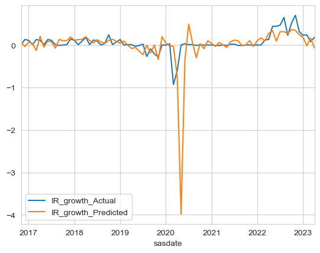

```python
result['IR_growth_Actual'].plot(legend=True)
result['IR_growth_Predicted'].plot(legend=True)
```

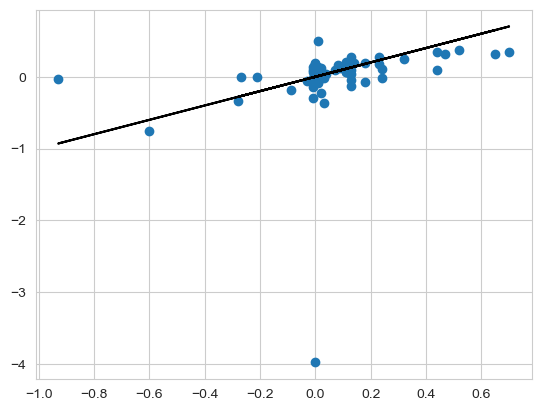

```python
plt.scatter(y_test_list, y_pred_list)
plt.plot(y_test_list, y_test_list,'k-') # identity line
```

```python
olsrfe_mse = metrics.mean_squared_error(y_test_list, y_pred_list, squared=False)
olsrfe_mse
```

```
0.4848576198504468
```

```python
olsrfe_r2 = metrics.r2_score(y_test_list, y_pred_list)
olsrfe_r2
```

```
-4.133047526786471
```

```python
model = "OLS with RFE"
r_square = olsrfe_r2
mse = olsrfe_mse
time = olsrfe_time

olsrfe_results = {
                    'Model': model,
                    'R-Squared': r_square,
                    'MSE': mse,
                    'Time': time
                  }
```

```python
final_results = pd.concat([final_results, pd.DataFrame([olsrfe_results])], ignore_index=True)
final_results
```

|  | Model | R-Squared | MSE | Time |
| --- | --- | --- | --- | --- |
| 0 | OLS | -6.845652 | 0.603126 | 2.325707 |
| 1 | OLS with PCA | -10.952001 | 0.739855 | 0.660926 |
| 2 | OLS with PCA in EN Reg. | -0.072702 | 0.221649 | 2.587655 |
| 3 | OLS with PCA in EN Reg. in S.W. | -0.072877 | 0.221667 | 1.376456 |
| 4 | OLS with RFE | -4.133048 | 0.484858 | 106.512999 |

For efficiency and simplicity, we would just use n_features_to_be_selected = 10

#### b. with Elastic Net

```python
# pipeline

# Steps
steps = [('scaler', StandardScaler(copy=True, with_mean=True, with_std=True)),
         ('rfe', RFE(LinearRegression(), n_features_to_select=10)),
         ('elastic_net', ElasticNet(random_state=42))
        ]

pipeline = Pipeline(steps)
```

```python
import time
```

```python
start=time.time()

n_trains = n_train + n_valid

n_records = n_train + n_valid + n_test

y_test_list = []

y_pred_list = []

j = 0

for i in range(n_trains, n_records):

    X_train, X_test, y_train, y_test = X[j:i], X[i:i+1], y[j:i], y[i:i+1]

    model = pipeline.fit(X_train, y_train)

    y_pred = model.predict(X_test)

    y_pred_list.extend(y_pred)

    y_test_list.extend(y_test)

    j += 1

end=time.time()

olsrfe_en_time = end-start
print("Running Time:", olsrfe_en_time)
```

```
Running Time: 107.4466700553894
```

```python
pd.options.display.max_rows=300
result = pd.DataFrame({'IR_growth_Actual': y[-n_test:], 'IR_growth_Predicted': y_pred_list}, columns=['IR_growth_Actual', 'IR_growth_Predicted'])
result
```

| sasdate | IR_growth_Actual | IR_growth_Predicted |
| --- | --- | --- |
| 2016-11-01 | 0.01 | -3.473227e-03 |
| 2016-12-01 | 0.13 | -3.690304e-03 |
| 2017-01-01 | 0.11 | -3.415340e-03 |
| 2017-02-01 | 0.01 | -3.965268e-03 |
| 2017-03-01 | 0.13 | -4.066570e-03 |
| 2017-04-01 | 0.11 | -3.921852e-03 |
| 2017-05-01 | 0.01 | -4.138929e-03 |
| 2017-06-01 | 0.13 | -4.442836e-03 |
| 2017-07-01 | 0.11 | -4.283647e-03 |
| 2017-08-01 | 0.01 | -4.109986e-03 |
| 2017-09-01 | -0.01 | -4.095514e-03 |
| 2017-10-01 | 0.00 | -4.081042e-03 |
| 2017-11-01 | 0.01 | -3.892909e-03 |
| 2017-12-01 | 0.14 | -3.994211e-03 |
| 2018-01-01 | 0.11 | -3.690304e-03 |
| 2018-02-01 | 0.01 | -2.764110e-03 |
| 2018-03-01 | 0.09 | -2.619392e-03 |
| 2018-04-01 | 0.18 | -2.127352e-03 |
| 2018-05-01 | 0.01 | -1.316932e-03 |
| 2018-06-01 | 0.12 | -1.114327e-03 |
| 2018-07-01 | 0.09 | -8.972504e-04 |
| 2018-08-01 | 0.00 | -1.013025e-04 |
| 2018-09-01 | 0.04 | 6.657019e-04 |
| 2018-10-01 | 0.24 | -8.538350e-04 |
| 2018-11-01 | 0.01 | 2.460203e-04 |
| 2018-12-01 | 0.07 | 1.027496e-03 |
| 2019-01-01 | 0.13 | 4.196816e-04 |
| 2019-02-01 | 0.00 | 9.696093e-04 |
| 2019-03-01 | 0.01 | 1.780029e-03 |
| 2019-04-01 | 0.01 | 5.933430e-04 |
| 2019-05-01 | -0.03 | 7.814761e-04 |
| 2019-06-01 | -0.01 | 1.881331e-04 |
| 2019-07-01 | 0.02 | -3.328509e-04 |
| 2019-08-01 | -0.27 | 1.013025e-04 |
| 2019-09-01 | -0.09 | -2.894356e-05 |
| 2019-10-01 | -0.21 | -4.775687e-04 |
| 2019-11-01 | -0.28 | -1.476122e-03 |
| 2019-12-01 | 0.00 | -1.780029e-03 |
| 2020-01-01 | 0.00 | -1.172214e-03 |
| 2020-02-01 | 0.03 | -1.635311e-03 |
| 2020-03-01 | -0.93 | -1.635311e-03 |
| 2020-04-01 | -0.60 | -3.299566e-03 |
| 2020-05-01 | 0.00 | -4.124457e-03 |
| 2020-06-01 | 0.03 | -4.124457e-03 |
| 2020-07-01 | 0.01 | -4.138929e-03 |
| 2020-08-01 | 0.01 | -4.109986e-03 |
| 2020-09-01 | -0.01 | -4.081042e-03 |
| 2020-10-01 | 0.00 | -4.211288e-03 |
| 2020-11-01 | 0.00 | -4.182344e-03 |
| 2020-12-01 | 0.00 | -4.066570e-03 |
| 2021-01-01 | 0.00 | -4.211288e-03 |
| 2021-02-01 | -0.01 | -4.196816e-03 |
| 2021-03-01 | -0.01 | -4.254703e-03 |
| 2021-04-01 | 0.00 | -4.949349e-03 |
| 2021-05-01 | -0.01 | -4.934877e-03 |
| 2021-06-01 | 0.02 | -4.978292e-03 |
| 2021-07-01 | 0.02 | -4.920405e-03 |
| 2021-08-01 | -0.01 | -4.746744e-03 |
| 2021-09-01 | -0.01 | -4.905933e-03 |
| 2021-10-01 | 0.00 | -4.920405e-03 |
| 2021-11-01 | 0.00 | -4.848046e-03 |
| 2021-12-01 | 0.00 | -4.905933e-03 |
| 2022-01-01 | 0.00 | -4.949349e-03 |
| 2022-02-01 | 0.00 | -4.949349e-03 |
| 2022-03-01 | 0.12 | -4.833575e-03 |
| 2022-04-01 | 0.13 | -4.775687e-03 |
| 2022-05-01 | 0.44 | -4.515195e-03 |
| 2022-06-01 | 0.44 | -3.748191e-03 |
| 2022-07-01 | 0.47 | -3.342981e-03 |
| 2022-08-01 | 0.65 | -3.140376e-03 |
| 2022-09-01 | 0.23 | -2.272069e-03 |
| 2022-10-01 | 0.52 | -2.054993e-03 |
| 2022-11-01 | 0.70 | -1.403763e-03 |
| 2022-12-01 | 0.32 | -4.486252e-04 |
| 2023-01-01 | 0.23 | -4.498733e-18 |
| 2023-02-01 | 0.24 | 4.052098e-04 |
| 2023-03-01 | 0.08 | 6.946454e-04 |
| 2023-04-01 | 0.18 | 7.670043e-04 |

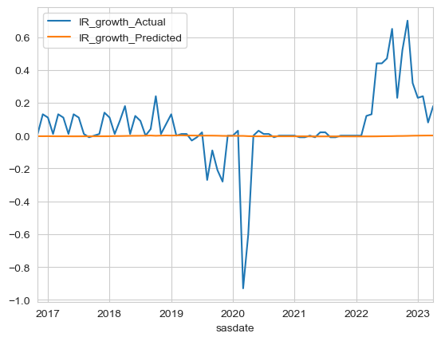

```python
result['IR_growth_Actual'].plot(legend=True)
result['IR_growth_Predicted'].plot(legend=True)
```

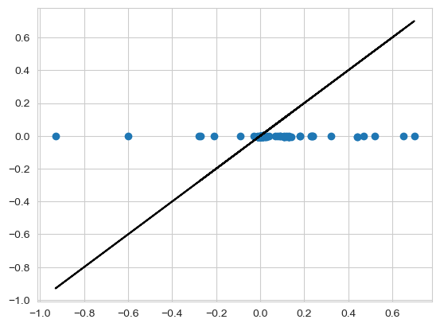

```python
plt.scatter(y_test_list, y_pred_list)
plt.plot(y_test_list, y_test_list,'k-') # identity line
```

```python
olsrfe_en_mse = metrics.mean_squared_error(y_test_list, y_pred_list, squared=False)
olsrfe_en_mse
```

```
0.22213205474775713
```

```python
olsrfe_en_r2 = metrics.r2_score(y_test_list, y_pred_list)
olsrfe_en_r2
```

```
-0.07738097625663776
```

```python
model = "OLS with RFE in EN Reg."
r_square = olsrfe_en_r2
mse = olsrfe_en_mse
time = olsrfe_en_time

olsrfe_en_results = {
                    'Model': model,
                    'R-Squared': r_square,
                    'MSE': mse,
                    'Time': time
                  }
```

```python
final_results = pd.concat([final_results, pd.DataFrame([olsrfe_en_results])], ignore_index=True)
final_results
```

|  | Model | R-Squared | MSE | Time |
| --- | --- | --- | --- | --- |
| 0 | OLS | -6.845652 | 0.603126 | 2.325707 |
| 1 | OLS with PCA | -10.952001 | 0.739855 | 0.660926 |
| 2 | OLS with PCA in EN Reg. | -0.072702 | 0.221649 | 2.587655 |
| 3 | OLS with PCA in EN Reg. in S.W. | -0.072877 | 0.221667 | 1.376456 |
| 4 | OLS with RFE | -4.133048 | 0.484858 | 106.512999 |
| 5 | OLS with RFE in EN Reg. | -0.077381 | 0.222132 | 107.446670 |

#### c. with Elastic Net, in sliding window instead of expanding window

```python
# pipeline

# Steps
steps = [('scaler', StandardScaler(copy=True, with_mean=True, with_std=True)),
         ('rfe', RFE(LinearRegression(), n_features_to_select=10)),
         ('elastic_net', ElasticNet(random_state=42))
        ]

pipeline = Pipeline(steps)
```

```python
import time
```

```python
# Final evaluation with sliding window
n_trains = n_train + n_valid
n_records = n_train + n_valid + n_test
y_test_list = []
y_pred_list = []
window_size = 120  # 10 years for monthly data

start = time.time()
for i in range(n_trains, n_records):
    start_idx = max(0, i - window_size)
    X_train, X_test = X[start_idx:i], X[i:i+1]
    y_train, y_test = y[start_idx:i], y[i:i+1]
    model = pipeline.fit(X_train, y_train)
    y_pred = model.predict(X_test)
    y_pred_list.extend(y_pred)
    y_test_list.extend(y_test)
end = time.time()

olsrfe_en_sw_time = end-start
print(f"Running Time: {olsrfe_en_sw_time:.4f} seconds")
```

```
Running Time: 37.9715 seconds
```

```python
# Calculate metrics
olsrfe_en_sw_mse = metrics.mean_squared_error(y_test_list, y_pred_list, squared=False)
olsrfe_en_sw_r2 = metrics.r2_score(y_test_list, y_pred_list)
print(f"Test RMSE: {olsrfe_en_sw_mse:.4f}")
print(f"Test R-squared: {olsrfe_en_sw_r2:.4f}")
```

```
Test RMSE: 0.2212
Test R-squared: -0.0679
```

```python
pd.options.display.max_rows=300
result = pd.DataFrame({'IR_growth_Actual': y[-n_test:], 'IR_growth_Predicted': y_pred_list}, columns=['IR_growth_Actual', 'IR_growth_Predicted'])
result
```

| sasdate | IR_growth_Actual | IR_growth_Predicted |
| --- | --- | --- |
| 2016-11-01 | 0.01 | -4.041667e-02 |
| 2016-12-01 | 0.13 | -4.033333e-02 |
| 2017-01-01 | 0.11 | -3.916667e-02 |
| 2017-02-01 | 0.01 | -3.833333e-02 |
| 2017-03-01 | 0.13 | -3.833333e-02 |
| 2017-04-01 | 0.11 | -3.725000e-02 |
| 2017-05-01 | 0.01 | -3.625000e-02 |
| 2017-06-01 | 0.13 | -3.616667e-02 |
| 2017-07-01 | 0.11 | -3.508333e-02 |
| 2017-08-01 | 0.01 | -3.425000e-02 |
| 2017-09-01 | -0.01 | -3.216667e-02 |
| 2017-10-01 | 0.00 | -3.158333e-02 |
| 2017-11-01 | 0.01 | -3.008333e-02 |
| 2017-12-01 | 0.14 | -2.775000e-02 |
| 2018-01-01 | 0.11 | -2.450000e-02 |
| 2018-02-01 | 0.01 | -2.108333e-02 |
| 2018-03-01 | 0.09 | -1.300000e-02 |
| 2018-04-01 | 0.18 | -9.166667e-03 |
| 2018-05-01 | 0.01 | -4.916667e-03 |
| 2018-06-01 | 0.12 | -2.333333e-03 |
| 2018-07-01 | 0.09 | -1.500000e-03 |
| 2018-08-01 | 0.00 | -8.333333e-04 |
| 2018-09-01 | 0.04 | -7.500000e-04 |
| 2018-10-01 | 0.24 | 1.166667e-03 |
| 2018-11-01 | 0.01 | 1.016667e-02 |
| 2018-12-01 | 0.07 | 1.508333e-02 |
| 2019-01-01 | 0.13 | 1.758333e-02 |
| 2019-02-01 | 0.00 | 1.875000e-02 |
| 2019-03-01 | 0.01 | 1.816667e-02 |
| 2019-04-01 | 0.01 | 1.858333e-02 |
| 2019-05-01 | -0.03 | 1.891667e-02 |
| 2019-06-01 | -0.01 | 1.841667e-02 |
| 2019-07-01 | 0.02 | 1.808333e-02 |
| 2019-08-01 | -0.27 | 1.866667e-02 |
| 2019-09-01 | -0.09 | 1.641667e-02 |
| 2019-10-01 | -0.21 | 1.575000e-02 |
| 2019-11-01 | -0.28 | 1.425000e-02 |
| 2019-12-01 | 0.00 | 1.191667e-02 |
| 2020-01-01 | 0.00 | 1.191667e-02 |
| 2020-02-01 | 0.03 | 1.200000e-02 |
| 2020-03-01 | -0.93 | 1.208333e-02 |
| 2020-04-01 | -0.60 | 4.083333e-03 |
| 2020-05-01 | 0.00 | -1.250000e-03 |
| 2020-06-01 | 0.03 | -1.250000e-03 |
| 2020-07-01 | 0.01 | -8.333333e-04 |
| 2020-08-01 | 0.01 | -7.500000e-04 |
| 2020-09-01 | -0.01 | -7.500000e-04 |
| 2020-10-01 | 0.00 | -8.333333e-04 |
| 2020-11-01 | 0.00 | -8.333333e-04 |
| 2020-12-01 | 0.00 | -8.333333e-04 |
| 2021-01-01 | 0.00 | -7.500000e-04 |
| 2021-02-01 | -0.01 | -6.666667e-04 |
| 2021-03-01 | -0.01 | -6.666667e-04 |
| 2021-04-01 | 0.00 | -5.833333e-04 |
| 2021-05-01 | -0.01 | -2.500000e-04 |
| 2021-06-01 | 0.02 | -2.500000e-04 |
| 2021-07-01 | 0.02 | -8.333333e-05 |
| 2021-08-01 | -0.01 | 2.500000e-04 |
| 2021-09-01 | -0.01 | -8.333333e-05 |
| 2021-10-01 | 0.00 | -6.938894e-18 |
| 2021-11-01 | 0.00 | 8.333333e-05 |
| 2021-12-01 | 0.00 | -6.938894e-18 |
| 2022-01-01 | 0.00 | 8.333333e-05 |
| 2022-02-01 | 0.00 | -6.938894e-18 |
| 2022-03-01 | 0.12 | -1.666667e-04 |
| 2022-04-01 | 0.13 | 5.833333e-04 |
| 2022-05-01 | 0.44 | 1.583333e-03 |
| 2022-06-01 | 0.44 | 5.083333e-03 |
| 2022-07-01 | 0.47 | 8.750000e-03 |
| 2022-08-01 | 0.65 | 1.266667e-02 |
| 2022-09-01 | 0.23 | 1.833333e-02 |
| 2022-10-01 | 0.52 | 2.016667e-02 |
| 2022-11-01 | 0.70 | 2.433333e-02 |
| 2022-12-01 | 0.32 | 3.016667e-02 |
| 2023-01-01 | 0.23 | 3.283333e-02 |
| 2023-02-01 | 0.24 | 3.491667e-02 |
| 2023-03-01 | 0.08 | 3.683333e-02 |
| 2023-04-01 | 0.18 | 3.758333e-02 |

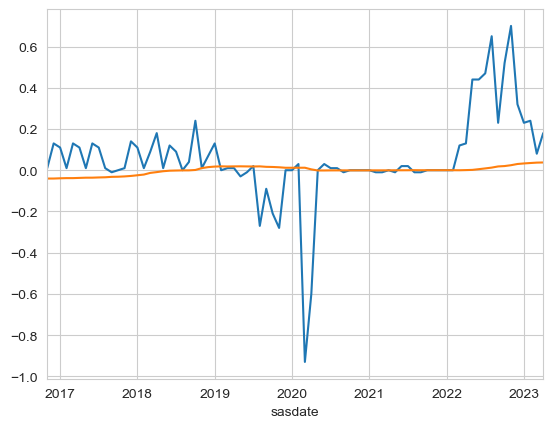

```python
result['IR_growth_Actual'].plot(label='Actual')
result['IR_growth_Predicted'].plot(label='Preducted')
```

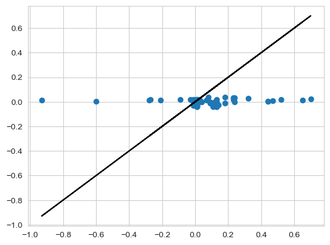

```python
plt.scatter(y_test_list, y_pred_list)
plt.plot(y_test_list, y_test_list,'k-') # identity line
```

```python
model = "OLS with RFE in EN Reg. in S.W."
r_square = olsrfe_en_sw_r2
mse = olsrfe_en_sw_mse
time = olsrfe_en_sw_time

olsrfe_en_sw_results = {
                    'Model': model,
                    'R-Squared': r_square,
                    'MSE': mse,
                    'Time': time
                  }
```

```python
final_results = pd.concat([final_results, pd.DataFrame([olsrfe_en_sw_results])], ignore_index=True)
final_results
```

|  | Model | R-Squared | MSE | Time |
| --- | --- | --- | --- | --- |
| 0 | OLS | -6.845652 | 0.603126 | 2.325707 |
| 1 | OLS with PCA | -10.952001 | 0.739855 | 0.660926 |
| 2 | OLS with PCA in EN Reg. | -0.072702 | 0.221649 | 2.587655 |
| 3 | OLS with PCA in EN Reg. in S.W. | -0.072877 | 0.221667 | 1.376456 |
| 4 | OLS with RFE | -4.133048 | 0.484858 | 106.512999 |
| 5 | OLS with RFE in EN Reg. | -0.077381 | 0.222132 | 107.446670 |
| 6 | OLS with RFE in EN Reg. in S.W. | -0.067880 | 0.221150 | 37.971492 |

### D. Baseline model with SelectKBest

```python
fred_md_df = pd.read_csv('cleaned_US FRED-MD Macro Dataset.csv')
tcode_df = pd.read_csv('cleaned_tcode.csv')
```

```python
# Extracting the 'group' row and dropping the 'Unnamed: 0' column
groups = tcode_df.iloc[1, 1:].astype(int)

# Extracting the feature data (excluding 'sasdate') and target variable ('FEDFUNDS') from the FRED-MD dataset
features = fred_md_df.drop(columns=['sasdate', 'FEDFUNDS'])
target = fred_md_df['FEDFUNDS']

# Dictionary to store selected features for each group
selected_features_per_group = {}
```

```python
# Only keep columns that are present in both datasets
common_columns = features.columns.intersection(groups.index)

# Adjusting the groups to include only common columns
groups_aligned = groups[common_columns]

# Run the SelectKBest procedure for each unique group using the aligned features
selected_features_per_group = {}

for group in groups_aligned.unique():
    # Get columns that belong to the current group
    group_columns = groups_aligned[groups_aligned == group].index
    group_features = features[group_columns]

    # Apply SelectKBest to select top variables
    selector = SelectKBest(score_func=f_regression, k='all')
    selector.fit(group_features, target)

    # Store the feature scores for the current group
    selected_features_per_group[group] = pd.DataFrame({
        'Feature': group_columns,
        'Score': selector.scores_
    }).sort_values(by='Score', ascending=False)

# Display the selected features and their scores for each group
selected_features_per_group
```

```
{1:       Feature      Score
 2      INDPRO  40.101024
 12  IPMANSICS  39.307424
 15     CUMFNS  39.162728
 11     IPNMAT  36.264897
 9       IPMAT  33.240411
 10     IPDMAT  32.504954
 3     IPFPNSS  32.143914
 8     IPBUSEQ  26.872714
 4     IPFINAL  24.364501
 5     IPCONGD  14.798060
 6    IPDCONGD  12.574465
 1     W875RX1   8.499884
 7    IPNCONGD   4.259693
 13  IPB51222S   2.365242
```

[output cut: 116 more lines]

• Group 1: • Top variables: INDPRO, IPMANSICS, CUMFNS • Group 2: • Top variables: DMANEMP, MANEMP, USGOOD • Group 3: • Top variables: PERMIT, HOUST, HOUSTS • Group 4: • Top variables: AMDMUOX, BUSINVX, CMRMTSPLX • Group 5: • Top variables: M2SL, M2REAL, NONBORRES Group 6: • Top variables: CP3MX, TB3MS, TB6MS • Group 7: • Top variables: CPIULFSL, CUSR0000SAS, CUSR0000SA0L5 • Group 8: • Top variables: VIXCLSX, S&P DIV YIELD, S&P PE RATIO

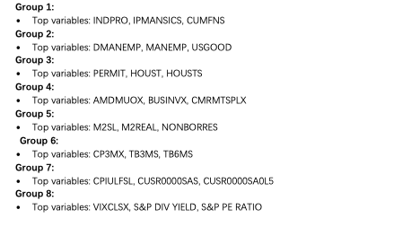

```python
final_results
```

|  | Model | R-Squared | MSE | Time |
| --- | --- | --- | --- | --- |
| 0 | OLS | -6.845652 | 0.603126 | 2.325707 |
| 1 | OLS with PCA | -10.952001 | 0.739855 | 0.660926 |
| 2 | OLS with PCA in EN Reg. | -0.072702 | 0.221649 | 2.587655 |
| 3 | OLS with PCA in EN Reg. in S.W. | -0.072877 | 0.221667 | 1.376456 |
| 4 | OLS with RFE | -4.133048 | 0.484858 | 106.512999 |
| 5 | OLS with RFE in EN Reg. | -0.077381 | 0.222132 | 107.446670 |
| 6 | OLS with RFE in EN Reg. in S.W. | -0.067880 | 0.221150 | 37.971492 |

### Short Conclusion

Alternatively, for SelectKBest, despite the computational cost being less high, for our regression task, it is using F-stat, which measures how well a feature explains the variance in the target variable relative to the variance explained by other features. [2] discusses how multicollinearity affects t-statistics but mentions that it does not directly affect the F-statistic. This indicates that while feature selection methods like SelectKBest may help identify important features, they do not resolve underlying multicollinearity issues.

Therefore, we are only using PCA to tackle the multicolinearity issue, instead of RFE and SelectKBest.

[1] https://www.analyticsvidhya.com/blog/2023/05/recursive-feature-elimination/#:~:text=RFE%20can%20handle%20multicollinearity%20but,can%20also%20deal%20with%20multicollinearity.

[2] https://www.analystforum.com/t/multicollinearity-and-f-stat/52731

## iv. Classification for features appending

Target types:

- interest rate actual values
- interest rate spread

Model types:

- Logistic Regression
- Decision Tree Classifier
- SGD classifier
- SVM
- XGBoost Classifier

```python
# Sklearn
from sklearn import metrics
from sklearn.metrics import make_scorer
from sklearn.metrics import accuracy_score
from sklearn.metrics import mean_absolute_error
from sklearn.model_selection import train_test_split
from sklearn.metrics import r2_score, mean_squared_error
from sklearn import metrics
from sklearn.metrics import roc_curve, auc, classification_report, confusion_matrix, accuracy_score
from sklearn.metrics import  accuracy_score, f1_score, precision_score, recall_score, roc_auc_score

from sklearn import linear_model
from sklearn.linear_model import LinearRegression
from sklearn.linear_model import LogisticRegression
from sklearn.linear_model import Ridge
from sklearn.linear_model import Lasso
from sklearn.linear_model import ElasticNet
from sklearn.linear_model import SGDRegressor
from sklearn.linear_model import SGDClassifier
from sklearn.cluster import KMeans
from sklearn.decomposition import PCA
from sklearn.ensemble import RandomForestClassifier
from sklearn.tree import DecisionTreeClassifier
from sklearn.svm import SVC


from sklearn.pipeline import Pipeline
from sklearn.preprocessing import StandardScaler
from sklearn.preprocessing import MinMaxScaler
from sklearn.model_selection import TimeSeriesSplit
from sklearn.model_selection import RandomizedSearchCV
from sklearn.model_selection import GridSearchCV

# XGBoost
import xgboost as xgb
```

### A. Data Reconstruction

#### a. Import Data & Transformation to classes

```python
def multi_class_transform(zero_range, val):
    zero_min = zero_range[0]
    zero_max = zero_range[1]
    for i in range(len(df)):
        if val <= zero_max and  val >= zero_min:
            return 0
        elif df[i] > zero_max:
            return 1
        else:
            return -1

def trans_actual_trend(val):
    if val < 0:
        return -1
    elif val > 0:
        return 1
    else:
        return 0
```

```python
df = pd.read_csv('cleaned_US FRED-MD Macro Dataset.csv', header=0, index_col=0, parse_dates=True)
features = df.drop('FEDFUNDS', axis=1)
features

target = df
target = target[["FEDFUNDS"]]
target

X_start = 0 # Starting from 1959-03-01
X_lag = 1

# Features and Target
X = features.iloc[X_start:].shift(X_lag).dropna()
y = target.loc[X.index]

zero_range = [-0.2, 0.2]

X, y = df.iloc[X_start:,:-1].shift(X_lag).dropna(), target.iloc[X_start+X_lag:] # Use X_t-1 to predict y_t

train_split = 0.8
valid_split = 0.1
test_split = 0.1

n_train = int(train_split*len(X))
n_valid = int(valid_split*len(X))
n_test = len(X)-n_train-n_valid

print(n_train, n_valid, n_test)
```

```
615 76 78
```

```python
y_train = y[:615]["FEDFUNDS"]

trans_y_target = []
for i in y_train:
    trans_y_target.append(trans_actual_trend(i))
trans_y_target
```

[output not shown]

[output cut: 560 more lines]

[output not shown]

```python
X_train = X[:615]
X_train
```

| sasdate | RPI | W875RX1 | DPCERA3M086SBEA | CMRMTSPLX | RETAILX | INDPRO | IPFPNSS | IPFINAL | IPCONGD | IPDCONGD | ... | DDURRG3M086SBEA | DNDGRG3M086SBEA | DSERRG3M086SBEA | CES0600000008 | CES2000000008 | CES3000000008 | UMCSENTX | DTCOLNVHFNM | DTCTHFNM | INVEST |
| --- | --- | --- | --- | --- | --- | --- | --- | --- | --- | --- | --- | --- | --- | --- | --- | --- | --- | --- | --- | --- | --- |
| 1959-04-01 | 0.643011 | 0.735934 | 0.941009 | -0.342293 | 0.832120 | 1.430562 | 0.603538 | 0.489413 | 0.000000 | 1.939253 | ... | 0.066630 | -0.112407 | 0.026180 | -0.002184 | -0.814665 | 0.481883 | 0.000000 | 0.492915 | 0.413844 | -1.479236 |
| 1959-05-01 | 0.649412 | 0.704864 | -0.363947 | 1.992210 | 0.061571 | 2.107542 | 1.433800 | 1.454467 | 1.565020 | 0.638320 | ... | -0.022927 | 0.134899 | 0.175237 | -0.002163 | 1.220345 | -0.488953 | 0.000000 | 1.213403 | 0.673430 | 2.492924 |
| 1959-06-01 | 0.576311 | 0.661646 | 1.200535 | 0.679731 | 0.780340 | 1.495451 | 0.826987 | 0.958168 | 0.477012 | 2.014866 | ... | 0.064631 | -0.168653 | -0.193673 | -0.002143 | -0.408972 | -0.481929 | 9.158924 | 0.282830 | 0.202040 | -1.534223 |
| 1959-07-01 | 0.310244 | 0.297379 | 0.370829 | -0.005152 | 0.906434 | 0.114146 | 0.703443 | 0.712756 | -0.476704 | 0.745726 | ... | 0.032895 | 0.331580 | 0.209340 | -0.461895 | 0.399176 | 0.479617 | -9.158924 | 0.972627 | 0.900669 | -1.225183 |
| 1959-08-01 | -0.058921 | -0.076384 | -0.342687 | 1.211007 | -0.033018 | -2.424000 | 0.116761 | 0.824894 | 1.305354 | 1.960539 | ... | -0.152071 | -0.123781 | -0.010035 | 0.000000 | -0.404015 | -0.479617 | 0.000000 | -0.463064 | -0.099954 | 2.934128 |
| ... | ... | ... | ... | ... | ... | ... | ... | ... | ... | ... | ... | ... | ... | ... | ... | ... | ... | ... | ... | ... | ... |
| 2010-02-01 | 0.502783 | -0.140978 | -0.183134 | -0.286323 | -0.007513 | 1.064382 | 0.941994 | 1.006122 | 0.662906 | 1.185635 | ... | 0.096114 | 0.359036 | 0.102812 | 0.199303 | 0.304243 | 0.054274 | 1.900000 | 5.087069 | 1.032371 | -1.075862 |
| 2010-03-01 | 0.042126 | -0.035276 | 0.373238 | 0.658135 | 0.189391 | 0.342608 | -0.415131 | -0.561516 | -0.839116 | -1.619028 | ... | -0.226692 | -0.620105 | -0.090575 | -0.050086 | -0.218289 | 0.216655 | -0.800000 | -5.890401 | -1.264694 | 0.156043 |
| 2010-04-01 | 0.378774 | 0.400646 | 0.476801 | 1.260029 | 2.124646 | 0.717776 | 0.828757 | 0.923701 | 0.357439 | 1.420630 | ... | 0.211512 | 0.217453 | 0.111845 | -0.049862 | -0.086975 | -0.325057 | 0.000000 | 18.730787 | -0.097242 | -0.606642 |
| 2010-05-01 | 0.813112 | 1.035544 | 0.204390 | 0.890386 | 0.887488 | 0.351272 | 0.214605 | -0.189122 | -0.830165 | 0.274880 | ... | -0.240566 | -0.068605 | -0.070487 | 0.049492 | -0.346489 | 0.216421 | -1.400000 | -17.590365 | 0.589606 | 0.329849 |
| 2010-06-01 | 0.782436 | 0.953266 | 0.248440 | -0.313577 | -0.924767 | 1.364637 | 1.386938 | 1.675105 | 1.867501 | 3.731787 | ... | 0.110932 | -0.219410 | 0.020589 | -0.000221 | 0.389901 | 0.269206 | 1.400000 | -0.353299 | -0.053370 | -0.422066 |

615 rows × 123 columns

#### b. Import Data & Transformation to classes

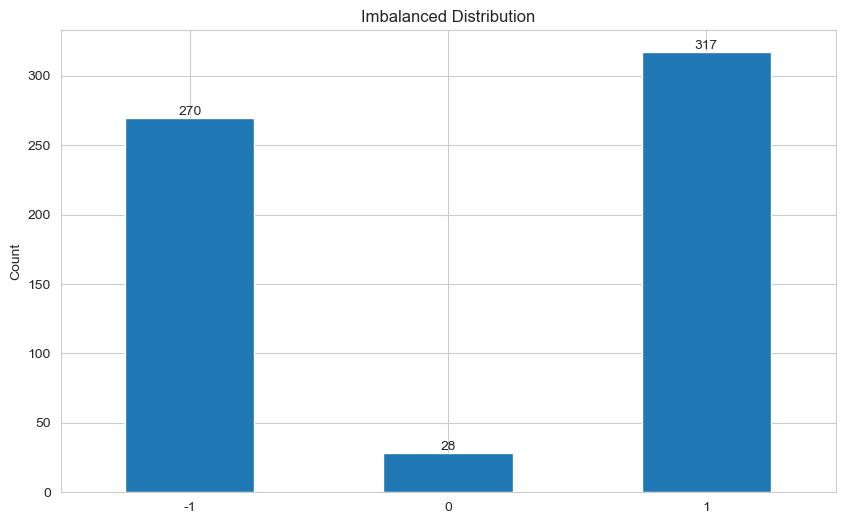

```python
counts = pd.Series(trans_y_target).value_counts().reindex([-1, 0, 1], fill_value=0)

# Create the bar plot
ax = counts.plot(kind='bar', figsize=(10, 6), title="Imbalanced Distribution")

# Set x-tick labels
ax.set_xticklabels(['-1', '0', '1'], rotation=0)

# Add counts on top of each bar
for i in ax.patches:
    ax.annotate(f'{int(i.get_height())}',
                (i.get_x() + i.get_width() / 2, i.get_height()),
                ha='center', va='bottom')

# Show the plot
plt.ylabel('Count')  # Optional: Label for y-axis
plt.show()
```

As we observe, the class imbalace situation is significant. It is actually normal since with FEDFUND transformed, firstly, y = first difference of y, i.e [y_t - y_t-1]. Hence, no change would be rare. Therefore, we would try to use SMOTE, instead of under/oversampling, to get the similar feature behaviour of 0 and -1 class, to keep the feature instead of simply duplicating or removing; To preserve the most important feature. In comparision, without SMOTE's result is in the report.

```python
smote = SMOTE(random_state=42)
X_train_smote, y_train_smote = smote.fit_resample(X_train, trans_y_target)
```

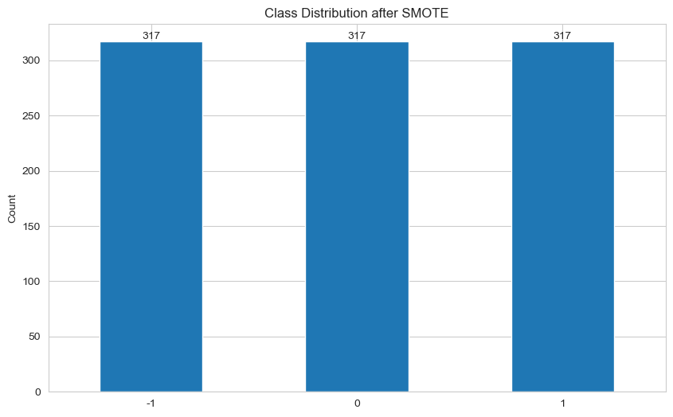

```python
counts = pd.Series(y_train_smote).value_counts().reindex([-1, 0, 1], fill_value=0)

# Create the bar plot
ax = counts.plot(kind='bar', figsize=(10, 6), title="Class Distribution after SMOTE")

# Set x-tick labels
ax.set_xticklabels(['-1', '0', '1'], rotation=0)

# Add counts on top of each bar
for i in ax.patches:
    ax.annotate(f'{int(i.get_height())}',
                (i.get_x() + i.get_width() / 2, i.get_height()),
                ha='center', va='bottom')

# Show the plot
plt.ylabel('Count')  # Optional: Label for y-axis
plt.show()
```

```python
X_train_smote
```

|  | RPI | W875RX1 | DPCERA3M086SBEA | CMRMTSPLX | RETAILX | INDPRO | IPFPNSS | IPFINAL | IPCONGD | IPDCONGD | ... | DDURRG3M086SBEA | DNDGRG3M086SBEA | DSERRG3M086SBEA | CES0600000008 | CES2000000008 | CES3000000008 | UMCSENTX | DTCOLNVHFNM | DTCTHFNM | INVEST |
| --- | --- | --- | --- | --- | --- | --- | --- | --- | --- | --- | --- | --- | --- | --- | --- | --- | --- | --- | --- | --- | --- |
| 0 | 0.643011 | 0.735934 | 0.941009 | -0.342293 | 0.832120 | 1.430562 | 0.603538 | 0.489413 | 0.000000 | 1.939253 | ... | 0.066630 | -0.112407 | 0.026180 | -0.002184 | -0.814665 | 0.481883 | 0.000000 | 0.492915 | 0.413844 | -1.479236 |
| 1 | 0.649412 | 0.704864 | -0.363947 | 1.992210 | 0.061571 | 2.107542 | 1.433800 | 1.454467 | 1.565020 | 0.638320 | ... | -0.022927 | 0.134899 | 0.175237 | -0.002163 | 1.220345 | -0.488953 | 0.000000 | 1.213403 | 0.673430 | 2.492924 |
| 2 | 0.576311 | 0.661646 | 1.200535 | 0.679731 | 0.780340 | 1.495451 | 0.826987 | 0.958168 | 0.477012 | 2.014866 | ... | 0.064631 | -0.168653 | -0.193673 | -0.002143 | -0.408972 | -0.481929 | 9.158924 | 0.282830 | 0.202040 | -1.534223 |
| 3 | 0.310244 | 0.297379 | 0.370829 | -0.005152 | 0.906434 | 0.114146 | 0.703443 | 0.712756 | -0.476704 | 0.745726 | ... | 0.032895 | 0.331580 | 0.209340 | -0.461895 | 0.399176 | 0.479617 | -9.158924 | 0.972627 | 0.900669 | -1.225183 |
| 4 | -0.058921 | -0.076384 | -0.342687 | 1.211007 | -0.033018 | -2.424000 | 0.116761 | 0.824894 | 1.305354 | 1.960539 | ... | -0.152071 | -0.123781 | -0.010035 | 0.000000 | -0.404015 | -0.479617 | 0.000000 | -0.463064 | -0.099954 | 2.934128 |
| ... | ... | ... | ... | ... | ... | ... | ... | ... | ... | ... | ... | ... | ... | ... | ... | ... | ... | ... | ... | ... | ... |
| 946 | 0.450497 | 0.464911 | 0.410289 | -0.189333 | -0.144412 | -0.536361 | -0.754676 | -0.745023 | -0.773323 | -0.668733 | ... | -0.078733 | -0.933543 | -0.278670 | -0.088352 | -0.035750 | -0.131223 | 7.276552 | 4.974922 | 0.479924 | 0.116358 |
| 947 | 0.331137 | 0.334031 | 0.202589 | 1.511826 | 0.566534 | -0.073824 | -0.200522 | -0.259751 | -0.452445 | -0.326596 | ... | -0.030676 | -0.645908 | -0.036859 | -0.013210 | -0.426438 | 0.125492 | 2.356841 | 0.332023 | 0.248011 | -0.435772 |
| 948 | 0.405487 | 0.462563 | 0.101984 | 1.096382 | 0.665005 | 0.509627 | 0.523666 | 0.437791 | 0.469033 | -0.036041 | ... | 0.120221 | -0.589914 | -0.166124 | -0.736772 | -2.850447 | -0.091760 | 0.731620 | 0.234349 | -0.393367 | -0.350671 |
| 949 | 0.431923 | 0.455027 | 0.488915 | -0.266138 | -0.130141 | 0.469331 | 0.381127 | 0.477642 | 0.677124 | 0.221570 | ... | -0.037512 | -0.329478 | 0.128884 | -0.227202 | -0.543851 | -0.290276 | -1.364853 | -0.078663 | 0.508262 | -1.869203 |
| 950 | 0.109177 | -0.009669 | 0.169622 | 0.415220 | 0.485304 | 0.343053 | 0.100534 | -0.059242 | -0.018140 | 0.919034 | ... | 0.072678 | 0.257929 | 0.029903 | 0.021687 | 0.066659 | -0.108203 | -2.263973 | 0.687735 | 0.465370 | -0.730738 |

951 rows × 123 columns

```python
len(y_train_smote)
```

```
951
```

### B. Logistic Regression

```python
cs = [0.0001, 0.001, 0.01, 0.1, 1]
l1_ratios = [0, 0.1, 0.2, 0.5, 0.9, 1]

try_grid = [{'C': cs,
             'l1_ratio': l1_ratios
           }]
try_grid

# Initialize the Logistic Regression model
log_reg = LogisticRegression(penalty = 'elasticnet', random_state=42, solver = 'saga', multi_class='ovr')

# Initialize GridSearchCV with F1 scoring
LOGIT = GridSearchCV(log_reg, param_grid=try_grid, cv=10, scoring='f1_weighted')

# Fit the model on the training data
LOGIT.fit(X_train_smote, y_train_smote)
```

```
GridSearchCV(cv=10,
             estimator=LogisticRegression(multi_class='ovr',
                                          penalty='elasticnet', random_state=42,
                                          solver='saga'),
             param_grid=[{'C': [0.0001, 0.001, 0.01, 0.1, 1],
                          'l1_ratio': [0, 0.1, 0.2, 0.5, 0.9, 1]}],
             scoring='f1_weighted')
```

```python
# Retrieve best parameters and best score
print("Best Parameters:", LOGIT.best_params_)
print("Best Score (F1):", LOGIT.best_score_)
```

```
Best Parameters: {'C': 1, 'l1_ratio': 0.9}
Best Score (F1): 0.5193140034528716
```

```python
# Pipeline
# Steps
steps_logit = [('scaler', StandardScaler(copy=True, with_mean=True, with_std=True)),
               ('logit', LogisticRegression(penalty='elasticnet', C = 1, random_state=42, solver = 'saga', multi_class='ovr', l1_ratio = 0.9))
              ]

logit = Pipeline(steps_logit)
X_test = X[615:]
y_test = y[615:]["FEDFUNDS"]

for i in range(len(y_test)):
    y_test[i] = trans_actual_trend(y_test[i])
t0 = time.time() #Start ML -- Time Starts
logit.fit(X_train_smote, y_train_smote)
time_logit = time.time()-t0
print("Training time:", time_logit)
y_pred_logit = logit.predict(X_test)  # predicted class label
y_prob_logit = logit.predict_proba(X_test)  #predicted probability

acc = accuracy_score(y_test, y_pred_logit)
prec = precision_score(y_test, y_pred_logit, average='weighted')
rec = recall_score(y_test, y_pred_logit, average='weighted')
f1 = f1_score(y_test, y_pred_logit, average='weighted')
roc = roc_auc_score(pd.get_dummies(y_test), y_prob_logit, multi_class='ovr')

# Create a new row as a dictionary
logit_results = {'Model': 'Logistic Regression',
               'Accuracy': acc,
               'Precision': prec,
               'Recall': rec,
               'F1 Score': f1,
               'ROC': roc,
               'Time Required': time_logit}

results_df = pd.DataFrame(columns = ['Model', 'Accuracy', 'Precision', 'Recall', 'F1 Score', 'ROC', 'Time'])
# Append the new result using append (deprecated)
results_df = pd.DataFrame(logit_results, index=[0])

# Display the updated results DataFrame
results_df
```

```
Training time: 0.28797101974487305
```

|  | Model | Accuracy | Precision | Recall | F1 Score | ROC | Time Required |
| --- | --- | --- | --- | --- | --- | --- | --- |
| 0 | Logistic Regression | 0.422078 | 0.449694 | 0.422078 | 0.431881 | 0.584569 | 0.287971 |

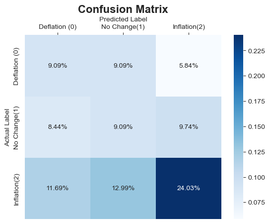

```python
# Create confusion matrix
logit_cm = metrics.confusion_matrix(y_test, y_pred_logit)

# Create a heatmap for the confusion matrix
fig, ax = plt.subplots()
sns.heatmap(logit_cm / np.sum(logit_cm), annot=True, fmt='.2%', cmap='Blues')

# Move X-axis labels and ticks to the top
ax.xaxis.set_label_position('top')  # Move X-axis label to top
ax.xaxis.tick_top()  # Move X-axis ticks to top

plt.title('Confusion Matrix', fontweight='bold', fontsize=16)
plt.ylabel('Actual Label')
plt.xlabel('Predicted Label')

# Set custom tick labels
ax.xaxis.set_ticklabels(['Deflation (0)', 'No Change(1)', 'Inflation(2)'])
ax.yaxis.set_ticklabels(['Deflation (0)', 'No Change(1)', 'Inflation(2)'])

plt.show()
```

Before and after SMOTE class redistribution,

| Model | Accuracy | Precision | Recall | F1 Score | ROC |
| --- | --- | --- | --- | --- | --- |
| Logistic Regression | 0.487013 | 0.41959 | 0.487013 | 0.43032 | 0.595458 |
| Logistic Regression after SMOTE | 0.422078 | 0.449694 | 0.422078 | 0.431881 | 0.584569 |

As we observe, the accuracy is decreased, which is normal since class imbalance would produce biased prediction, like predicting mostly 1 and -1 instead of 0. As a result, the precision ("Out of the fish we have caught, how many of this is actually fish") would be **lower before SMOTE**. As a result, the F1 score in this logistic regression after SMOTE is slightly higher as well.

### B. Decision Tree Classifier

```python
max_depths = [3, 4, 5, 7, 9, 15]
max_leaf_node = [5, 10, 20, 50]
min_samples_splits = [3, 5, 10]

try_grid = [{'max_depth': max_depths,
             'max_leaf_nodes': max_leaf_node,
             'min_samples_split': min_samples_splits
           }]

DTC = GridSearchCV(DecisionTreeClassifier(random_state=42), param_grid = try_grid, cv = 10, scoring='f1_weighted')
DTC.fit(X_train_smote, y_train_smote)
```

```
GridSearchCV(cv=10, estimator=DecisionTreeClassifier(random_state=42),
             param_grid=[{'max_depth': [3, 4, 5, 7, 9, 15],
                          'max_leaf_nodes': [5, 10, 20, 50],
                          'min_samples_split': [3, 5, 10]}],
             scoring='f1_weighted')
```

```python
print(f"Best DTC Hyperparameter: {DTC.best_params_}")
print(f"Best Score (F1): {DTC.best_score_}")
```

```
Best DTC Hyperparameter: {'max_depth': 7, 'max_leaf_nodes': 20, 'min_samples_split': 3}
Best Score (F1): 0.7000731479988314
```

```python
dtc = DecisionTreeClassifier(max_depth = 7, max_leaf_nodes = 20, min_samples_split = 3, random_state=42)
t0 = time.time() #Start ML -- Time Starts
dtc.fit(X_train_smote, y_train_smote)
time_dtc = time.time()-t0
```

```python
y_pred_dtc = dtc.predict(X_test)  # predicted class label
y_prob_dtc = dtc.predict_proba(X_test)   #predicted probability

acc = accuracy_score(y_test, y_pred_dtc)
prec = precision_score(y_test, y_pred_dtc, average='weighted')
rec = recall_score(y_test, y_pred_dtc, average='weighted')
f1 = f1_score(y_test, y_pred_dtc, average='weighted')
roc = roc_auc_score(pd.get_dummies(y_test), y_prob_dtc, multi_class='ovr')

# Create a new row as a dictionary
dtc_results = {'Model': 'Decision Tree Classifier',
               'Accuracy': acc,
               'Precision': prec,
               'Recall': rec,
               'F1 Score': f1,
               'ROC': roc,
               'Time Required': time_dtc}

               # Append the new result using append (deprecated)
results_df = pd.DataFrame(dtc_results, index=[0])

# Display the updated results DataFrame
results_df
```

|  | Model | Accuracy | Precision | Recall | F1 Score | ROC | Time Required |
| --- | --- | --- | --- | --- | --- | --- | --- |
| 0 | Decision Tree Classifier | 0.402597 | 0.470338 | 0.402597 | 0.41746 | 0.580923 | 0.097049 |

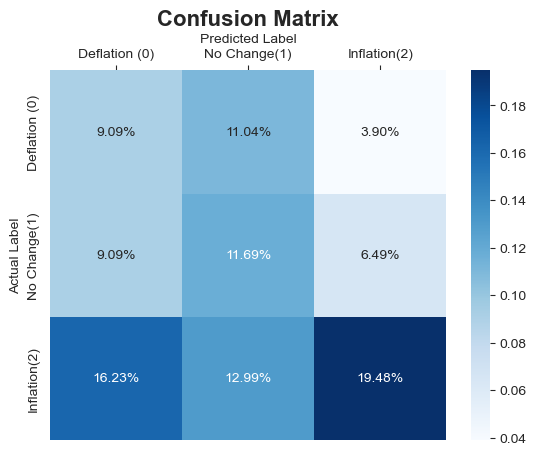

```python
# Create confusion matrix
dtc_cm = metrics.confusion_matrix(y_test, y_pred_dtc)

# Create a heatmap for the confusion matrix
fig, ax = plt.subplots()
sns.heatmap(dtc_cm / np.sum(dtc_cm), annot=True, fmt='.2%', cmap='Blues')

# Move X-axis labels and ticks to the top
ax.xaxis.set_label_position('top')  # Move X-axis label to top
ax.xaxis.tick_top()  # Move X-axis ticks to top

plt.title('Confusion Matrix', fontweight='bold', fontsize=16)
plt.ylabel('Actual Label')
plt.xlabel('Predicted Label')

# Set custom tick labels
ax.xaxis.set_ticklabels(['Deflation (0)', 'No Change(1)', 'Inflation(2)'])
ax.yaxis.set_ticklabels(['Deflation (0)', 'No Change(1)', 'Inflation(2)'])

plt.show()
```

Before and after SMOTE class redistribution,

| Model | Accuracy | Precision | Recall | F1 Score | ROC |
| --- | --- | --- | --- | --- | --- |
| Decision Tree Classifier | 0.38961 | 0.285561 | 0.38961 | 0.329518 | 0.544689 |
| Decision Tree Classifier (after SMOTE) | 0.402597 | 0.470338 | 0.402597 | 0.41746 | 0.580923 |

As we can see, after the SMOTE redistribution, the Decision Tree Classifier's f1 score is **much higher**, and the accuracy is higher as well.

### C. SGD Classifier

```python
alphas = np.logspace(-5, 2, 8) # 8 trials
l1_ratios = [0, 0.25, 0.5, 0.75, 1]
learning_rates = ['optimal', 'invscaling', 'adaptive']
eta0s = [0.001, 0.01, 0.1] # Initial learning rate


try_grid = [{'alpha': alphas,
             'l1_ratio': l1_ratios,
             'learning_rate': learning_rates,
             'eta0': eta0s
           }]

# Initialize the SGD Classifier model
SGD_cla = SGDClassifier(penalty = 'elasticnet', random_state=42, early_stopping=True, n_iter_no_change=5)

# Initialize GridSearchCV with F1 scoring
SGDC = GridSearchCV(SGD_cla, param_grid=try_grid, cv = 10, scoring='f1_weighted')

SGDC.fit(X_train_smote, y_train_smote)
```

```
GridSearchCV(cv=10,
             estimator=SGDClassifier(early_stopping=True, penalty='elasticnet',
                                     random_state=42),
             param_grid=[{'alpha': array([1.e-05, 1.e-04, 1.e-03, 1.e-02, 1.e-01, 1.e+00, 1.e+01, 1.e+02]),
                          'eta0': [0.001, 0.01, 0.1],
                          'l1_ratio': [0, 0.25, 0.5, 0.75, 1],
                          'learning_rate': ['optimal', 'invscaling',
                                            'adaptive']}],
             scoring='f1_weighted')
```

```python
print(f"Best SGD Hyperparameter: {SGDC.best_params_}")
print(f"Best Score (F1): {SGDC.best_score_}")
```

```
Best SGD Hyperparameter: {'alpha': 0.1, 'eta0': 0.1, 'l1_ratio': 0.25, 'learning_rate': 'adaptive'}
Best Score (F1): 0.615911001751887
```

```python
# Pipeline
steps_sgdc = [('scaler', StandardScaler(copy=True, with_mean=True, with_std=True)),
              ('sgdc', SGDClassifier(loss='log', penalty = 'elasticnet', alpha = 0.1, l1_ratio = 0.25, learning_rate = 'adaptive',
                                     eta0 = 0.1, random_state=42, early_stopping=True, n_iter_no_change=5))
             ]

sdgc = Pipeline(steps_sgdc)
t0 = time.time() #Start ML -- Time Starts
sdgc.fit(X_train_smote, y_train_smote)
time_sgd = time.time()-t0
y_pred_sgdc = sdgc.predict(X_test)  # predicted class label
y_prob_sgdc = sdgc.predict_proba(X_test)   #predicted probability

acc = accuracy_score(y_test, y_pred_sgdc)
prec = precision_score(y_test, y_pred_sgdc, average='weighted')
rec = recall_score(y_test, y_pred_sgdc, average='weighted')
f1 = f1_score(y_test, y_pred_sgdc, average='weighted')
roc = roc_auc_score(pd.get_dummies(y_test), y_prob_sgdc, multi_class='ovr')

# Create a new row as a dictionary
sgdc_results = {'Model': 'SGD Classifier',
               'Accuracy': acc,
               'Precision': prec,
               'Recall': rec,
               'F1 Score': f1,
               'ROC': roc,
               'Time Required': time_sgd}

results_df = pd.DataFrame(sgdc_results, index=[0])

# Display the updated results DataFrame
results_df
```

|  | Model | Accuracy | Precision | Recall | F1 Score | ROC | Time Required |
| --- | --- | --- | --- | --- | --- | --- | --- |
| 0 | SGD Classifier | 0.383117 | 0.429496 | 0.383117 | 0.39579 | 0.57766 | 0.16638 |

As we observe, the F1 score is way lower than the training dataset (0.61591 --> 0.39579), which might implies overfitting issue. Hence, we try to increase the alpha for penalty to e.g. 0.5:

```python
# New SGDC to reduce overfitting issue
steps_sgdc = [('scaler', StandardScaler(copy=True, with_mean=True, with_std=True)),
              ('sgdc', SGDClassifier(loss='log', penalty = 'elasticnet', alpha = 0.5, l1_ratio = 0.25, learning_rate = 'adaptive',
                                     eta0 = 0.1, random_state=42, early_stopping=True, n_iter_no_change=5))
             ]

sdgc = Pipeline(steps_sgdc)
t0 = time.time() #Start ML -- Time Starts
sdgc.fit(X_train_smote, y_train_smote)
time_sgd = time.time()-t0
y_pred_sgdc = sdgc.predict(X_test)  # predicted class label
y_prob_sgdc = sdgc.predict_proba(X_test)   #predicted probability

acc = accuracy_score(y_test, y_pred_sgdc)
prec = precision_score(y_test, y_pred_sgdc, average='weighted')
rec = recall_score(y_test, y_pred_sgdc, average='weighted')
f1 = f1_score(y_test, y_pred_sgdc, average='weighted')
roc = roc_auc_score(pd.get_dummies(y_test), y_prob_sgdc, multi_class='ovr')

# Create a new row as a dictionary
sgdc_results = {'Model': 'SGD Classifier',
               'Accuracy': acc,
               'Precision': prec,
               'Recall': rec,
               'F1 Score': f1,
               'ROC': roc,
               'Time Required': time_sgd}

results_df = pd.DataFrame(sgdc_results, index=[0])

# Display the updated results DataFrame
results_df
```

|  | Model | Accuracy | Precision | Recall | F1 Score | ROC | Time Required |
| --- | --- | --- | --- | --- | --- | --- | --- |
| 0 | SGD Classifier | 0.454545 | 0.482376 | 0.454545 | 0.457457 | 0.583508 | 0.173469 |

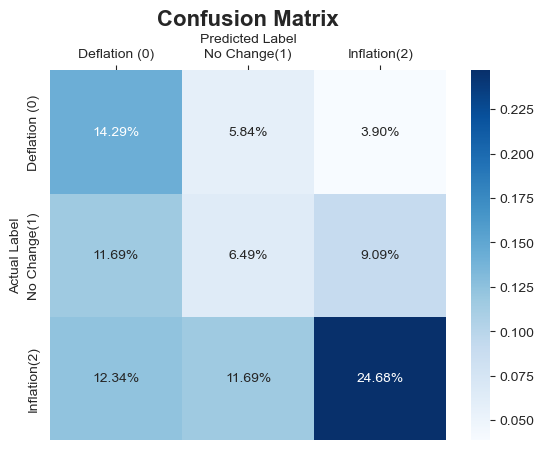

```python
# Create confusion matrix
sgdc_cm = metrics.confusion_matrix(y_test, y_pred_sgdc)

# Create a heatmap for the confusion matrix
fig, ax = plt.subplots()
sns.heatmap(sgdc_cm / np.sum(sgdc_cm), annot=True, fmt='.2%', cmap='Blues')

# Move X-axis labels and ticks to the top
ax.xaxis.set_label_position('top')  # Move X-axis label to top
ax.xaxis.tick_top()  # Move X-axis ticks to top

plt.title('Confusion Matrix', fontweight='bold', fontsize=16)
plt.ylabel('Actual Label')
plt.xlabel('Predicted Label')

# Set custom tick labels
ax.xaxis.set_ticklabels(['Deflation (0)', 'No Change(1)', 'Inflation(2)'])
ax.yaxis.set_ticklabels(['Deflation (0)', 'No Change(1)', 'Inflation(2)'])

plt.show()
```

Before and after SMOTE class redistribution & Reset the alpha,

| Model | Accuracy | Precision | Recall | F1 Score | ROC |
| --- | --- | --- | --- | --- | --- |
| SGD Classifier | 0.519481 | 0.377195 | 0.519481 | 0.437035 | 0.610604 |
| SGD Classifier (after SMOTE) | 0.454545 | 0.482376 | 0.454545 | 0.457457 | 0.583508 |

As we observe, after re-adjusting the alpha value to higher, having higher penalty, the f1 score slightly increase ~2%, with Precision much higher than before. This implies our model can classifier each class more accurately.

### D. Support Vector Machine

```python
# Define the parameter grid
param_grid = {
    'svc__C': [0.0001, 0.001, 0.01, 0.1, 1],  # Regularization parameter
    'svc__kernel': ['linear', 'poly', 'rbf', 'sigmoid'],  # Kernel types
}

# Create a pipeline with scaling and SVC
pipeline = Pipeline([
    ('scaler', StandardScaler(copy=True, with_mean=True, with_std=True)),
    ('svc', SVC(random_state=42))
])

# Initialize GridSearchCV with F1 scoring
SVM = GridSearchCV(pipeline, param_grid=param_grid, cv=10, scoring='f1_weighted')

# Fit the model on the training data
SVM.fit(X_train_smote, y_train_smote)
```

```
GridSearchCV(cv=10,
             estimator=Pipeline(steps=[('scaler', StandardScaler()),
                                       ('svc', SVC(random_state=42))]),
             param_grid={'svc__C': [0.0001, 0.001, 0.01, 0.1, 1],
                         'svc__kernel': ['linear', 'poly', 'rbf', 'sigmoid']},
             scoring='f1_weighted')
```

```python
# Retrieve best parameters and best score
print("Best Parameters:", SVM.best_params_)
print("Best Score (F1):", SVM.best_score_)
```

```
Best Parameters: {'svc__C': 1, 'svc__kernel': 'rbf'}
Best Score (F1): 0.7651881023925041
```

```python
# Pipeline
svm = [('scaler', StandardScaler(copy=True, with_mean=True, with_std=True)),
       ('svc', SVC(C = 1, kernel = 'rbf', random_state=42))
      ]

svm = Pipeline(steps_sgdc)
t0 = time.time() #Start ML -- Time Starts
svm.fit(X_train_smote, y_train_smote)
time_svm = time.time()-t0
y_pred_svm = svm.predict(X_test)  # predicted class label
y_prob_svm = svm.predict_proba(X_test)   #predicted probability

acc = accuracy_score(y_test, y_pred_svm)
prec = precision_score(y_test, y_pred_svm, average='weighted')
rec = recall_score(y_test, y_pred_svm, average='weighted')
f1 = f1_score(y_test, y_pred_svm, average='weighted')
roc = roc_auc_score(pd.get_dummies(y_test), y_prob_svm, multi_class='ovr')

# Create a new row as a dictionary
svm_results = {'Model': 'SVM',
               'Accuracy': acc,
               'Precision': prec,
               'Recall': rec,
               'F1 Score': f1,
               'ROC': roc,
               'Time Required': time_svm}


results_df = pd.DataFrame(svm_results, index=[0])

# Display the updated results DataFrame
results_df
```

|  | Model | Accuracy | Precision | Recall | F1 Score | ROC | Time Required |
| --- | --- | --- | --- | --- | --- | --- | --- |
| 0 | SVM | 0.454545 | 0.482376 | 0.454545 | 0.457457 | 0.583508 | 0.167402 |

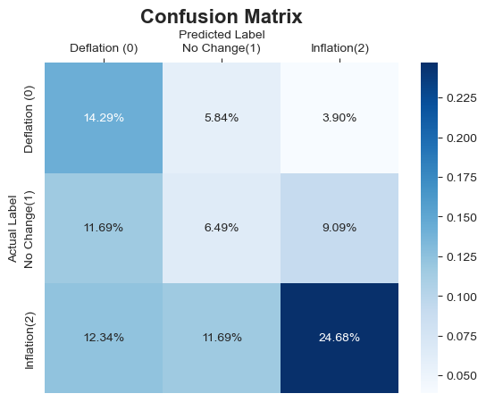

```python
# Create confusion matrix
svm_cm = metrics.confusion_matrix(y_test, y_pred_svm)

# Create a heatmap for the confusion matrix
fig, ax = plt.subplots()
sns.heatmap(svm_cm / np.sum(svm_cm), annot=True, fmt='.2%', cmap='Blues')

# Move X-axis labels and ticks to the top
ax.xaxis.set_label_position('top')  # Move X-axis label to top
ax.xaxis.tick_top()  # Move X-axis ticks to top

plt.title('Confusion Matrix', fontweight='bold', fontsize=16)
plt.ylabel('Actual Label')
plt.xlabel('Predicted Label')

# Set custom tick labels
ax.xaxis.set_ticklabels(['Deflation (0)', 'No Change(1)', 'Inflation(2)'])
ax.yaxis.set_ticklabels(['Deflation (0)', 'No Change(1)', 'Inflation(2)'])

plt.show()
```

Before and after SMOTE class redistribution,

[output not shown]

### E. XGBoost Classifier

```python
len(trans_y_target)
```

```
615
```

```python
def trans_actual_trend(val):
    if val < 0:
        return 0
    elif val > 0:
        return 2
    else:
        return 1

y_train = y[:615]["FEDFUNDS"]

trans_y_target = []
for i in y_train:
    trans_y_target.append(trans_actual_trend(i))

for i in range(len(y_test)):
    y_test[i] = trans_actual_trend(y_test[i])

trans_y_target
```

[output not shown]

[output cut: 560 more lines]

[output not shown]

```python
X_train_smote, trans_y_train_smote = smote.fit_resample(X_train, trans_y_target)
```

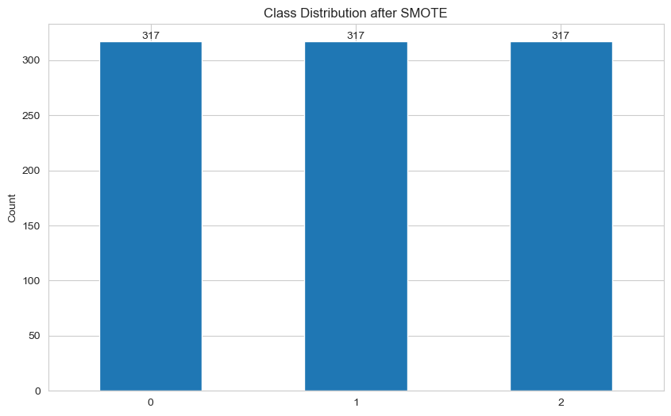

```python
counts = pd.Series(trans_y_train_smote).value_counts().reindex([0, 1, 2], fill_value=0)

# Create the bar plot
ax = counts.plot(kind='bar', figsize=(10, 6), title="Class Distribution after SMOTE")

# Set x-tick labels
ax.set_xticklabels(['0', '1', '2'], rotation=0)

# Add counts on top of each bar
for i in ax.patches:
    ax.annotate(f'{int(i.get_height())}',
                (i.get_x() + i.get_width() / 2, i.get_height()),
                ha='center', va='bottom')

# Show the plot
plt.ylabel('Count')  # Optional: Label for y-axis
plt.show()
```

```python
# Define the parameter grid
param_grid = {
    'xgb__n_estimators': [50, 100],  # Number of boosting rounds
    'xgb__max_depth': [3, 5],        # Maximum depth of trees
    'xgb__learning_rate': [0.01, 0.1],  # Learning rate
    'xgb__subsample': [0.5, 0.7]      # Fraction of samples for each tree
}

# Create a pipeline with scaling and XGBClassifier
pipeline = Pipeline([
    ('scaler', StandardScaler()),
    ('xgb', xgb.XGBClassifier(use_label_encoder=False, eval_metric='mlogloss', random_state=42))
])

# Initialize GridSearchCV with F1 scoring
XGBOOST = GridSearchCV(pipeline, param_grid=param_grid, cv=10, scoring='f1_weighted')

# Fit the model on the training data
XGBOOST.fit(X_train_smote, trans_y_train_smote)
```

```
GridSearchCV(cv=10,
             estimator=Pipeline(steps=[('scaler', StandardScaler()),
                                       ('xgb',
                                        XGBClassifier(base_score=None,
                                                      booster=None,
                                                      callbacks=None,
                                                      colsample_bylevel=None,
                                                      colsample_bynode=None,
                                                      colsample_bytree=None,
                                                      device=None,
                                                      early_stopping_rounds=None,
                                                      enable_categorical=False,
                                                      eval_metric='mlogloss',
                                                      feature_types=None,
                                                      gamma=None,
                                                      grow_policy=None,
                                                      importance_...
                                                      max_delta_step=None,
                                                      max_depth=None,
                                                      max_leaves=None,
                                                      min_child_weight=None,
                                                      missing=nan,
                                                      monotone_constraints=None,
                                                      multi_strategy=None,
                                                      n_estimators=None,
                                                      n_jobs=None,
                                                      num_parallel_tree=None,
                                                      random_state=42, ...))]),
             param_grid={'xgb__learning_rate': [0.01, 0.1],
                         'xgb__max_depth': [3, 5],
                         'xgb__n_estimators': [50, 100],
                         'xgb__subsample': [0.5, 0.7]},
             scoring='f1_weighted')
```

```python
# Retrieve best parameters and best score after fitting
print("Best Parameters:", XGBOOST.best_params_)
print("Best Score (F1):", XGBOOST.best_score_)
```

```
Best Parameters: {'xgb__learning_rate': 0.1, 'xgb__max_depth': 5, 'xgb__n_estimators': 50, 'xgb__subsample': 0.5}
Best Score (F1): 0.7611114698245138
```

```python
# Create a pipeline with scaling and XGBClassifier
steps_xgboost = [
    ('scaler', StandardScaler()),
    ('xgb', xgb.XGBClassifier(
        use_label_encoder=False,
        eval_metric='mlogloss',
        random_state=42,
        learning_rate=0.1,
        max_depth=5,
        n_estimators=50,
        subsample=0.5
    ))
]

# Initialize the pipeline
xgboost = Pipeline(steps_xgboost)
t0 = time.time() #Start ML -- Time Starts
xgboost.fit(X_train_smote, trans_y_train_smote)
time_xgb = time.time()-t0

y_pred_xgb = xgboost.predict(X_test)  # predicted class label
y_prob_xgb = xgboost.predict_proba(X_test)   #predicted probability

acc = accuracy_score(y_test, y_pred_xgb)
prec = precision_score(y_test, y_pred_xgb, average='weighted')
rec = recall_score(y_test, y_pred_xgb, average='weighted')
f1 = f1_score(y_test, y_pred_xgb, average='weighted')
roc = roc_auc_score(pd.get_dummies(y_test), y_prob_xgb, multi_class='ovr')

# Create a new row as a dictionary
xgb_results = {'Model': 'XGBoost Classifier',
               'Accuracy': acc,
               'Precision': prec,
               'Recall': rec,
               'F1 Score': f1,
               'ROC': roc,
               'Time Required': time_xgb}

results_df = pd.DataFrame(xgb_results, index=[0])

# Display the updated results DataFrame
results_df
```

|  | Model | Accuracy | Precision | Recall | F1 Score | ROC | Time Required |
| --- | --- | --- | --- | --- | --- | --- | --- |
| 0 | XGBoost Classifier | 0.532468 | 0.535923 | 0.532468 | 0.530071 | 0.696564 | 0.643396 |

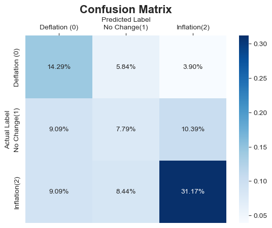

```python
# Create confusion matrix
xgb_cm = metrics.confusion_matrix(y_test, y_pred_xgb)

# Create a heatmap for the confusion matrix
fig, ax = plt.subplots()
sns.heatmap(xgb_cm / np.sum(xgb_cm), annot=True, fmt='.2%', cmap='Blues')

# Move X-axis labels and ticks to the top
ax.xaxis.set_label_position('top')  # Move X-axis label to top
ax.xaxis.tick_top()  # Move X-axis ticks to top

plt.title('Confusion Matrix', fontweight='bold', fontsize=16)
plt.ylabel('Actual Label')
plt.xlabel('Predicted Label')

# Set custom tick labels
ax.xaxis.set_ticklabels(['Deflation (0)', 'No Change(1)', 'Inflation(2)'])
ax.yaxis.set_ticklabels(['Deflation (0)', 'No Change(1)', 'Inflation(2)'])

plt.show()
```

Before and after SMOTE class redistribution,

| Model | Accuracy | Precision | Recall | F1 Score | ROC |
| --- | --- | --- | --- | --- | --- |
| XGBoost | 0.506494 | 0.366176 | 0.506494 | 0.424910 | 0.650393 |
| XGBoost (after SMOTE) | 0.532468 | 0.535923 | 0.532468 | 0.530071 | 0.696564 |

As we observe, F1 score is much higher after SMOTE, with accuracy having improvement as well. Basically all metrics have improvement after SMOTE in XGBoost Classifier

```python
class_final_results = pd.DataFrame(columns = ['Model', 'Accuracy', 'Precision', 'Recall', 'F1 Score', 'ROC', 'Time Required'])
class_final_results
```

|  | Model | Accuracy | Precision | Recall | F1 Score | ROC | Time Required |
| --- | --- | --- | --- | --- | --- | --- | --- |

```python
all_results = [logit_results, dtc_results, sgdc_results, svm_results, xgb_results]
```

```python
class_final_results = pd.concat([class_final_results, pd.DataFrame(all_results)], ignore_index=True)
class_final_results
```

|  | Model | Accuracy | Precision | Recall | F1 Score | ROC | Time Required |
| --- | --- | --- | --- | --- | --- | --- | --- |
| 0 | Logistic Regression | 0.422078 | 0.449694 | 0.422078 | 0.431881 | 0.584569 | 0.287971 |
| 1 | Decision Tree Classifier | 0.402597 | 0.470338 | 0.402597 | 0.417460 | 0.580923 | 0.097049 |
| 2 | SGD Classifier | 0.454545 | 0.482376 | 0.454545 | 0.457457 | 0.583508 | 0.173469 |
| 3 | SVM | 0.454545 | 0.482376 | 0.454545 | 0.457457 | 0.583508 | 0.167402 |
| 4 | XGBoost Classifier | 0.532468 | 0.535923 | 0.532468 | 0.530071 | 0.696564 | 0.643396 |

### Short Conclusion

According to the above table, it seems XGboost is the best of all models in our classification task.

## v. Regression Tasks begins

```python
X
```

| sasdate | RPI | W875RX1 | DPCERA3M086SBEA | CMRMTSPLX | RETAILX | INDPRO | IPFPNSS | IPFINAL | IPCONGD | IPDCONGD | ... | DDURRG3M086SBEA | DNDGRG3M086SBEA | DSERRG3M086SBEA | CES0600000008 | CES2000000008 | CES3000000008 | UMCSENTX | DTCOLNVHFNM | DTCTHFNM | INVEST |
| --- | --- | --- | --- | --- | --- | --- | --- | --- | --- | --- | --- | --- | --- | --- | --- | --- | --- | --- | --- | --- | --- |
| 1959-04-01 | 0.643011 | 0.735934 | 0.941009 | -0.342293 | 0.832120 | 1.430562 | 0.603538 | 0.489413 | 0.000000 | 1.939253 | ... | 0.066630 | -0.112407 | 0.026180 | -0.002184 | -0.814665 | 0.481883 | 0.000000 | 0.492915 | 0.413844 | -1.479236 |
| 1959-05-01 | 0.649412 | 0.704864 | -0.363947 | 1.992210 | 0.061571 | 2.107542 | 1.433800 | 1.454467 | 1.565020 | 0.638320 | ... | -0.022927 | 0.134899 | 0.175237 | -0.002163 | 1.220345 | -0.488953 | 0.000000 | 1.213403 | 0.673430 | 2.492924 |
| 1959-06-01 | 0.576311 | 0.661646 | 1.200535 | 0.679731 | 0.780340 | 1.495451 | 0.826987 | 0.958168 | 0.477012 | 2.014866 | ... | 0.064631 | -0.168653 | -0.193673 | -0.002143 | -0.408972 | -0.481929 | 9.158924 | 0.282830 | 0.202040 | -1.534223 |
| 1959-07-01 | 0.310244 | 0.297379 | 0.370829 | -0.005152 | 0.906434 | 0.114146 | 0.703443 | 0.712756 | -0.476704 | 0.745726 | ... | 0.032895 | 0.331580 | 0.209340 | -0.461895 | 0.399176 | 0.479617 | -9.158924 | 0.972627 | 0.900669 | -1.225183 |
| 1959-08-01 | -0.058921 | -0.076384 | -0.342687 | 1.211007 | -0.033018 | -2.424000 | 0.116761 | 0.824894 | 1.305354 | 1.960539 | ... | -0.152071 | -0.123781 | -0.010035 | 0.000000 | -0.404015 | -0.479617 | 0.000000 | -0.463064 | -0.099954 | 2.934128 |
| ... | ... | ... | ... | ... | ... | ... | ... | ... | ... | ... | ... | ... | ... | ... | ... | ... | ... | ... | ... | ... | ... |
| 2022-12-01 | 0.000898 | -0.075962 | -0.414455 | -0.947270 | -1.320097 | -0.330005 | -0.332552 | -0.400833 | -0.179349 | -2.240469 | ... | -0.174864 | -0.884680 | -0.056635 | 0.102595 | -0.062401 | 0.389154 | -3.100000 | 0.162379 | -0.007056 | 0.959749 |
| 2023-01-01 | -0.013781 | -0.019171 | -0.193846 | 1.490076 | -0.719328 | -1.550613 | -1.202485 | -0.846966 | -0.623823 | -1.031771 | ... | 0.344041 | -0.613838 | 0.175427 | -0.107940 | 0.300155 | -0.590025 | 2.900000 | -0.283245 | -0.123254 | 0.880929 |
| 2023-02-01 | 0.087570 | 0.130699 | 1.316033 | 0.190398 | 2.764501 | 1.003181 | 0.343776 | -0.014901 | -0.334291 | 0.217564 | ... | 0.474433 | 1.425376 | 0.033243 | 0.170724 | -0.004386 | 0.309575 | 5.200000 | 0.071035 | 0.049043 | -0.142513 |
| 2023-03-01 | 0.103913 | -0.004103 | -0.028459 | -0.417590 | -0.660515 | -0.005561 | -0.196666 | -0.129562 | 0.097723 | 0.212525 | ... | -0.436099 | -0.416042 | -0.224790 | -0.417543 | -0.152983 | -0.621376 | 2.100000 | -0.237727 | -0.068985 | -0.121427 |
| 2023-04-01 | 0.259530 | 0.284085 | -0.033085 | -0.945104 | -0.915446 | 0.146036 | -0.076300 | -0.030143 | 0.276299 | -1.061013 | ... | 0.100107 | -0.645568 | -0.081575 | 0.240091 | 0.027041 | 0.579697 | -5.000000 | 0.505030 | 0.343295 | -2.045412 |

769 rows × 123 columns

```python
y
```

| sasdate | FEDFUNDS |
| --- | --- |
| 1959-04-01 | 0.16 |
| 1959-05-01 | -0.06 |
| 1959-06-01 | 0.49 |
| 1959-07-01 | 0.08 |
| 1959-08-01 | 0.03 |
| ... | ... |
| 2022-12-01 | 2.00 |
| 2023-01-01 | 2.00 |
| 2023-02-01 | 2.00 |
| 2023-03-01 | 2.00 |
| 2023-04-01 | 2.00 |

769 rows × 1 columns

```python
# Store results
results_df = pd.DataFrame(columns=['Model', 'RMSE', 'R2'])
best_r2 = float('-inf')
best_params = None
```

### A. Decision Tree with PCA

```python
# Function to create a pipeline with PCA and Decision Tree Regressor
def create_pipeline(n_components, max_depth, min_samples_split):
    return Pipeline([
        ('scaler', StandardScaler()),
        ('pca', PCA(n_components=n_components, random_state=42)),
        ('model', DecisionTreeRegressor(
            max_depth=max_depth,
            min_samples_split=min_samples_split,
            random_state=42
        ))
    ])

# Expanding window validation function
def expanding_window_validation(pipeline, X, y, train_size, valid_size):
    predictions = []
    actuals = []

    for i in range(train_size, train_size + valid_size):
        # Use data up to t-1 to predict t
        X_train = X.iloc[:i]
        y_train = y.iloc[:i]
        X_test = X.iloc[i:i+1]
        y_test = y.iloc[i:i+1]

        model = pipeline.fit(X_train, y_train)
        pred = model.predict(X_test)
        predictions.append(pred[0])
        actuals.append(y_test.iloc[0])

    return np.array(predictions), np.array(actuals)
```

```python
# Grid search parameters
n_components_list = [5, 6, 7, 8, 9, 10]
max_depth_list = [3, 5, 7, 10]
min_samples_split_list = [2, 5, 10]
```

```python
# Combined Model Grid Search for Decision Tree with PCA
for n_comp in n_components_list:
    for max_depth in max_depth_list:
        for min_split in min_samples_split_list:
            pipeline = create_pipeline(n_comp, max_depth, min_split)

            valid_pred, valid_actual = expanding_window_validation(
                pipeline,
                X.iloc[:n_train+n_valid],
                y.iloc[:n_train+n_valid],
                n_train,
                n_valid
            )

            rmse = np.sqrt(mean_squared_error(valid_actual, valid_pred))
            r2 = r2_score(valid_actual, valid_pred)

            # Append results to DataFrame with model name included
            results_df = results_df.append({
                'Model': 'Decision Tree with PCA',
                'RMSE': rmse,
                'R2': r2
            }, ignore_index=True)

            if r2 > best_r2:
                best_r2 = r2
                best_params = (n_comp, max_depth, min_split)

# Print best parameters and R² score for Decision Tree with PCA
print("\nBest parameters:")
print(f"n_components={best_params[0]}, max_depth={best_params[1]}, min_samples_split={best_params[2]}")
print(f"Best R²: {best_r2:.4f}")
```

```
Best parameters:
n_components=5, max_depth=7, min_samples_split=10
Best R²: -1.1216
```

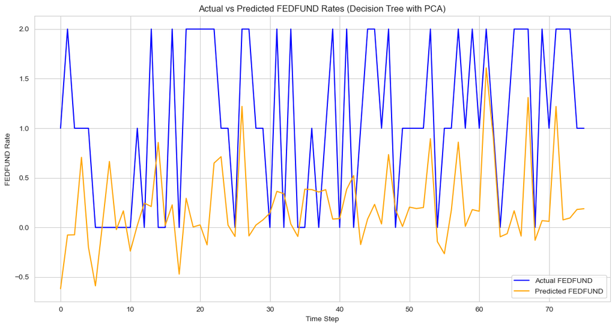

```python
# Visualisation of predicted vs actual values for the best model
best_pipeline = create_pipeline(best_params[0], best_params[1], best_params[2])

predicted_values, actual_values = expanding_window_validation(
    best_pipeline,
    X.iloc[:n_train+n_valid],
    y.iloc[:n_train+n_valid],
    n_train,
    n_valid
)

plt.figure(figsize=(14, 7))
plt.plot(actual_values, label='Actual FEDFUND', color='blue')
plt.plot(predicted_values, label='Predicted FEDFUND', color='orange')
plt.title('Actual vs Predicted FEDFUND Rates (Decision Tree with PCA)')
plt.xlabel('Time Step')
plt.ylabel('FEDFUND Rate')
plt.legend()
plt.show()
```

```python
# Display the results DataFrame sorted by R² score
results_df.sort_values("R2", ascending=False)
```

|  | Model | RMSE | R2 |
| --- | --- | --- | --- |
| 8 | Decision Tree with PCA | 1.175819 | -1.121575 |
| 3 | Decision Tree with PCA | 1.178006 | -1.129474 |
| 4 | Decision Tree with PCA | 1.178006 | -1.129474 |
| 5 | Decision Tree with PCA | 1.179626 | -1.135335 |
| 7 | Decision Tree with PCA | 1.185005 | -1.154856 |
| 6 | Decision Tree with PCA | 1.189814 | -1.172381 |
| 29 | Decision Tree with PCA | 1.196100 | -1.195395 |
| 28 | Decision Tree with PCA | 1.196444 | -1.196657 |
| 27 | Decision Tree with PCA | 1.196444 | -1.196657 |
| 68 | Decision Tree with PCA | 1.203663 | -1.223247 |
| 67 | Decision Tree with PCA | 1.205160 | -1.228779 |
| 17 | Decision Tree with PCA | 1.205919 | -1.231586 |
| 1 | Decision Tree with PCA | 1.205951 | -1.231706 |
| 0 | Decision Tree with PCA | 1.205951 | -1.231706 |
| 2 | Decision Tree with PCA | 1.205951 | -1.231706 |
| 59 | Decision Tree with PCA | 1.206382 | -1.233300 |
| 15 | Decision Tree with PCA | 1.209760 | -1.245827 |
| 16 | Decision Tree with PCA | 1.209760 | -1.245827 |
| 41 | Decision Tree with PCA | 1.210721 | -1.249395 |
| 39 | Decision Tree with PCA | 1.211061 | -1.250657 |
| 66 | Decision Tree with PCA | 1.211863 | -1.253640 |
| 40 | Decision Tree with PCA | 1.216143 | -1.269586 |
| 13 | Decision Tree with PCA | 1.223188 | -1.295959 |
| 12 | Decision Tree with PCA | 1.223188 | -1.295959 |
| 14 | Decision Tree with PCA | 1.223188 | -1.295959 |
| 56 | Decision Tree with PCA | 1.223383 | -1.296692 |
| 65 | Decision Tree with PCA | 1.224362 | -1.300368 |
| 64 | Decision Tree with PCA | 1.224698 | -1.301630 |
| 63 | Decision Tree with PCA | 1.224698 | -1.301630 |
| 57 | Decision Tree with PCA | 1.225674 | -1.305301 |
| 55 | Decision Tree with PCA | 1.227598 | -1.312544 |
| 58 | Decision Tree with PCA | 1.230978 | -1.325295 |
| 20 | Decision Tree with PCA | 1.231996 | -1.329142 |
| 53 | Decision Tree with PCA | 1.234199 | -1.337482 |
| 52 | Decision Tree with PCA | 1.234532 | -1.338744 |
| 51 | Decision Tree with PCA | 1.234532 | -1.338744 |
| 69 | Decision Tree with PCA | 1.234892 | -1.340107 |
| 47 | Decision Tree with PCA | 1.235850 | -1.343737 |
| 70 | Decision Tree with PCA | 1.238205 | -1.352679 |
| 44 | Decision Tree with PCA | 1.243471 | -1.372733 |
| 48 | Decision Tree with PCA | 1.244337 | -1.376041 |
| 49 | Decision Tree with PCA | 1.244337 | -1.376041 |
| 50 | Decision Tree with PCA | 1.244337 | -1.376041 |
| 25 | Decision Tree with PCA | 1.244638 | -1.377188 |
| 24 | Decision Tree with PCA | 1.244638 | -1.377188 |
| 26 | Decision Tree with PCA | 1.244638 | -1.377188 |
| 32 | Decision Tree with PCA | 1.244659 | -1.377267 |
| 42 | Decision Tree with PCA | 1.244857 | -1.378024 |
| 43 | Decision Tree with PCA | 1.246629 | -1.384801 |
| 60 | Decision Tree with PCA | 1.246643 | -1.384852 |
| 61 | Decision Tree with PCA | 1.246643 | -1.384852 |
| 62 | Decision Tree with PCA | 1.246643 | -1.384852 |
| 36 | Decision Tree with PCA | 1.246941 | -1.385994 |
| 38 | Decision Tree with PCA | 1.246941 | -1.385994 |
| 37 | Decision Tree with PCA | 1.246941 | -1.385994 |
| 54 | Decision Tree with PCA | 1.247785 | -1.389226 |
| 18 | Decision Tree with PCA | 1.248140 | -1.390585 |
| 19 | Decision Tree with PCA | 1.248781 | -1.393041 |
| 11 | Decision Tree with PCA | 1.249599 | -1.396179 |
| 71 | Decision Tree with PCA | 1.250129 | -1.398211 |
| 45 | Decision Tree with PCA | 1.252912 | -1.408898 |
| 9 | Decision Tree with PCA | 1.254436 | -1.414765 |
| 31 | Decision Tree with PCA | 1.263932 | -1.451460 |
| 10 | Decision Tree with PCA | 1.264320 | -1.452965 |
| 30 | Decision Tree with PCA | 1.267385 | -1.464875 |
| 35 | Decision Tree with PCA | 1.270663 | -1.477641 |
| 46 | Decision Tree with PCA | 1.272838 | -1.486130 |
| 34 | Decision Tree with PCA | 1.279369 | -1.511709 |
| 23 | Decision Tree with PCA | 1.298654 | -1.588002 |
| 33 | Decision Tree with PCA | 1.299780 | -1.592489 |
| 21 | Decision Tree with PCA | 1.322224 | -1.682796 |
| 22 | Decision Tree with PCA | 1.327130 | -1.702742 |

```python
best_results = results_df.sort_values("R2", ascending = False).head(1).reset_index(drop = True)
best_results
```

|  | Model | RMSE | R2 |
| --- | --- | --- | --- |
| 0 | Decision Tree with PCA | 1.175819 | -1.121575 |

### B. Random Forest Regression with PCA

```python
# Define a function to create the pipeline for Random Forest with PCA
def create_rf_pipeline(n_components):
    return Pipeline([
        ('scaler', StandardScaler()),
        ('pca', PCA(n_components=n_components, random_state=42)),
        ('rf', RandomForestRegressor(random_state=42))  # Random Forest Regressor
    ])

# Define hyperparameter grid for Random Forest
param_grid_rf = {
    'rf__n_estimators': [50, 100],  # Number of trees in the forest
    'rf__max_depth': [3, 5],      # Maximum depth of the tree
    'rf__min_samples_split': [2, 5]   # Minimum samples required to split an internal node
}

# Set up GridSearchCV for Random Forest
pipeline_rf = create_rf_pipeline(n_components=10)  # Start with a reasonable number of components
grid_search_rf = GridSearchCV(pipeline_rf, param_grid_rf, cv=5, scoring='r2', verbose=1)

# Fit the model using GridSearchCV for Random Forest
grid_search_rf.fit(X.iloc[:n_train], y.iloc[:n_train])

# Get best parameters and score for Random Forest
best_rf_params = grid_search_rf.best_params_
best_rf_score = grid_search_rf.best_score_

print("------------------------------------------------------------------------------------------------")
print("Best Random Forest parameters:", best_rf_params)
print("Best R² score from Random Forest:", best_rf_score)
```

```
Fitting 5 folds for each of 8 candidates, totalling 40 fits
------------------------------------------------------------------------------------------------
Best Random Forest parameters: {'rf__max_depth': 3, 'rf__min_samples_split': 2, 'rf__n_estimators': 50}
Best R² score from Random Forest: -0.2151143781847309
```

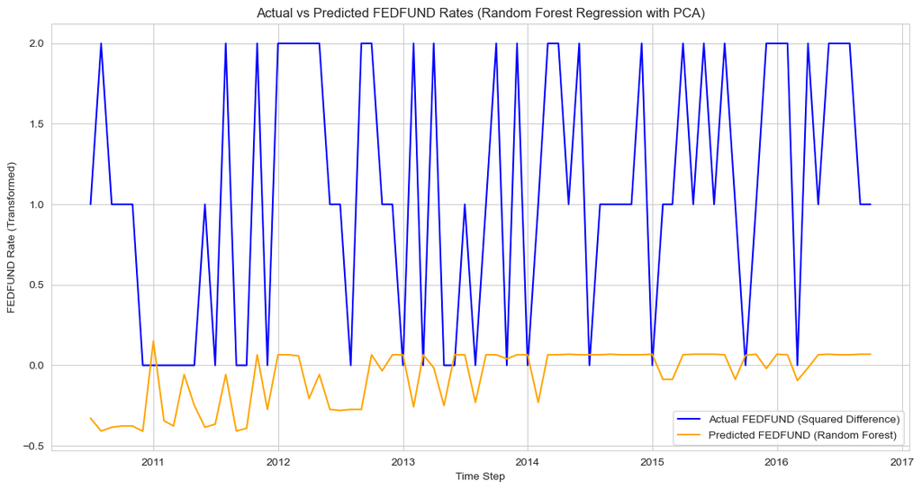

```python
# Visualize results for Random Forest (using validation set)
predicted_values_rf = grid_search_rf.predict(X.iloc[n_train:n_train+n_valid])
actual_values_rf = y.iloc[n_train:n_train+n_valid]

# Calculate RMSE and R² for Random Forest on validation set
rmse_rf = np.sqrt(mean_squared_error(actual_values_rf, predicted_values_rf))
r2_rf = r2_score(actual_values_rf, predicted_values_rf)

# Append results to best_results df
best_results = best_results.append({
    'RMSE': rmse_rf,
    'R2': r2_rf,
    'Model': 'Random Forest Regression with PCA'
}, ignore_index=True)

plt.figure(figsize=(14, 7))
plt.plot(actual_values_rf.index, actual_values_rf.values, label='Actual FEDFUND (Squared Difference)', color='blue')
plt.plot(actual_values_rf.index, predicted_values_rf, label='Predicted FEDFUND (Random Forest)', color='orange')
plt.title('Actual vs Predicted FEDFUND Rates (Random Forest Regression with PCA)')
plt.xlabel('Time Step')
plt.ylabel('FEDFUND Rate (Transformed)')
plt.legend()
plt.show()
```

```python
best_results
```

|  | Model | RMSE | R2 |
| --- | --- | --- | --- |
| 0 | Decision Tree with PCA | 1.175819 | -1.121575 |
| 1 | Random Forest Regression with PCA | 1.381059 | -1.926860 |

### C. SVM

```python
# Define a function to create the pipeline for SVM regression
def create_svm_pipeline():
    return Pipeline([
        ('scaler', StandardScaler()),  # Standardize features
        ('svm', SVR())  # Support Vector Regressor
    ])

# Define hyperparameter grid for SVM
param_grid_svm = {
    'svm__C': [0.1, 1, 10],  # Regularization parameter
    'svm__epsilon': [0.1, 0.2, 0.5],  # Epsilon in the epsilon-SVR model
    'svm__kernel': ['linear', 'rbf']  # Kernel types to be used in the algorithm
}

# Set up GridSearchCV for SVM
pipeline_svm = create_svm_pipeline()
grid_search_svm = GridSearchCV(pipeline_svm, param_grid_svm, cv=5, scoring='r2', verbose=1)

# Fit the model using GridSearchCV for SVM
grid_search_svm.fit(X.iloc[:n_train], y.iloc[:n_train])

# Get best parameters and score for SVM
best_svm_params = grid_search_svm.best_params_
best_svm_score = grid_search_svm.best_score_

print("------------------------------------------------------------------------------------------------")
print("Best SVM parameters:", best_svm_params)
print("Best R² score from SVM:", best_svm_score)
```

```
Fitting 5 folds for each of 18 candidates, totalling 90 fits
------------------------------------------------------------------------------------------------
Best SVM parameters: {'svm__C': 0.1, 'svm__epsilon': 0.1, 'svm__kernel': 'rbf'}
Best R² score from SVM: 0.17305927605144109
```

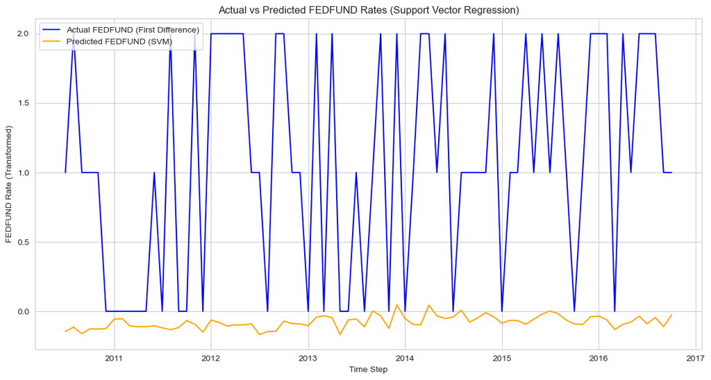

```python
# Visualize results for SVM (using validation set)
predicted_values_svm = grid_search_svm.predict(X.iloc[n_train:n_train+n_valid])
actual_values_svm = y.iloc[n_train:n_train+n_valid]

# Calculate RMSE and R² for SVM on validation set
rmse_svm = np.sqrt(mean_squared_error(actual_values_svm, predicted_values_svm))
r2_svm = r2_score(actual_values_svm, predicted_values_svm)

# Append results to best_results DataFrame
best_results = best_results.append({
    'RMSE': rmse_svm,
    'R2': r2_svm,
    'Model': 'Support Vector Regression'
}, ignore_index=True)

plt.figure(figsize=(14, 7))
plt.plot(actual_values_svm.index, actual_values_svm.values, label='Actual FEDFUND (First Difference)', color='blue')
plt.plot(actual_values_svm.index, predicted_values_svm, label='Predicted FEDFUND (SVM)', color='orange')
plt.title('Actual vs Predicted FEDFUND Rates (Support Vector Regression)')
plt.xlabel('Time Step')
plt.ylabel('FEDFUND Rate (Transformed)')
plt.legend()
plt.show()
```

```python
best_results
```

|  | Model | RMSE | R2 |
| --- | --- | --- | --- |
| 0 | Decision Tree with PCA | 1.175819 | -1.121575 |
| 1 | Random Forest Regression with PCA | 1.381059 | -1.926860 |
| 2 | Support Vector Regression | 1.402837 | -2.019898 |

### D. RNN + GARCH

#### a. Import Libraries

```python
import tensorflow as tf
from keras.models import Sequential
from keras.layers import Dense, Activation, Dropout, LSTM, SimpleRNN
from keras import optimizers
from keras.initializers import HeNormal
from keras.regularizers import l2

import math

import json
```

#### b. import Data

```python
# Actual Federal Funds Rate
Actual_Rate = pd.read_csv("actual_interest_rate.csv", header=0, index_col=0, parse_dates=True)[1:]
Actual_Rate
```

| sasdate | FEDFUNDS |
| --- | --- |
| 1959-04-01 | 0.16 |
| 1959-05-01 | -0.06 |
| 1959-06-01 | 0.49 |
| 1959-07-01 | 0.08 |
| 1959-08-01 | 0.03 |
| ... | ... |
| 2022-12-01 | 0.32 |
| 2023-01-01 | 0.23 |
| 2023-02-01 | 0.24 |
| 2023-03-01 | 0.08 |
| 2023-04-01 | 0.18 |

769 rows × 1 columns

```python
# Federal Funds Rate Spread
Rate_Spread = pd.read_csv("target_spread.csv", header=0, index_col=0, parse_dates=True)[1:]
Rate_Spread
```

| sasdate | FEDFUNDS |
| --- | --- |
| 1959-04-01 | -0.21 |
| 1959-05-01 | -0.22 |
| 1959-06-01 | 0.55 |
| 1959-07-01 | -0.41 |
| 1959-08-01 | -0.05 |
| ... | ... |
| 2022-12-01 | -0.38 |
| 2023-01-01 | -0.09 |
| 2023-02-01 | 0.01 |
| 2023-03-01 | -0.16 |
| 2023-04-01 | 0.10 |

769 rows × 1 columns

```python
# Read PCA independent variables
with open('structure.json') as f:
    dataframe = json.load(f)

inde_var = dataframe["reduced data layer"]
inde_var = pd.DataFrame(inde_var)

# Merge the column index
sasdate = Rate_Spread.index
inde_var.set_index(sasdate)
```

| sasdate | Group 1: Output and income1 | Group 1: Output and income2 | Group 1: Output and income3 | Group 1: Output and income4 | Group 1: Output and income5 | Group 1: Output and income6 | Group 1: Output and income7 | Group 2: Labor market1 | Group 2: Labor market2 | Group 2: Labor market3 | ... | Group 7: Prices3 | Group 7: Prices4 | Group 7: Prices5 | Group 7: Prices6 | Group 7: Prices7 | Group 7: Prices8 | Group 7: Prices9 | Group 7: Prices10 | Group 8: Stock market1 | Group 8: Stock market2 |
| --- | --- | --- | --- | --- | --- | --- | --- | --- | --- | --- | --- | --- | --- | --- | --- | --- | --- | --- | --- | --- | --- |
| 1959-04-01 | -3.013555 | 1.773530 | 0.568510 | 0.161061 | 0.995433 | 1.098525 | -1.093286 | -4.137322 | -0.607266 | -0.343140 | ... | -0.518914 | -1.504659 | 0.462679 | -0.480634 | 0.167128 | 0.869794 | -0.086662 | 1.410891 | -1.143059 | -0.164747 |
| 1959-05-01 | -5.150580 | -0.036687 | 1.142488 | 0.381140 | 1.678744 | 0.040036 | 1.289757 | -3.333807 | -2.948834 | 0.004639 | ... | 0.878200 | 1.102330 | 0.778180 | 1.679114 | 0.185986 | -1.914237 | -0.236813 | -1.028274 | -0.648187 | -0.009626 |
| 1959-06-01 | -3.294015 | 0.698079 | -0.167180 | -1.298126 | 1.507429 | 0.391030 | -0.191319 | -1.839345 | -1.670471 | 0.582233 | ... | -0.090954 | -0.160733 | -1.228645 | -1.582724 | -1.051888 | 0.811135 | 0.586927 | 0.154645 | -0.575956 | 0.024302 |
| 1959-07-01 | 0.165887 | 0.236160 | -0.639349 | -0.657401 | -0.930561 | -0.152282 | -0.059049 | -1.177160 | -0.315508 | -0.063384 | ... | -0.297850 | 0.437997 | 1.462024 | 0.518307 | 1.244029 | 1.057112 | -0.832400 | -0.011642 | 0.747203 | 0.113638 |
| 1959-08-01 | 4.465354 | -3.733575 | -0.393998 | 0.244805 | -4.088412 | -2.678166 | 4.043202 | -0.253158 | -1.310983 | 1.179764 | ... | 0.074872 | -0.504007 | -0.479937 | 0.988872 | -0.199730 | -1.865725 | 0.040971 | 0.396593 | -1.643247 | 0.292069 |
| ... | ... | ... | ... | ... | ... | ... | ... | ... | ... | ... | ... | ... | ... | ... | ... | ... | ... | ... | ... | ... | ... |
| 2022-12-01 | 1.978166 | -1.297509 | 0.307722 | 0.302802 | 0.540462 | 0.388454 | -0.041010 | -0.055012 | 0.012701 | -0.827884 | ... | 1.037143 | -0.151238 | 1.430813 | -1.727231 | -0.354969 | -1.252093 | 0.695796 | 0.834896 | -2.054412 | -0.327221 |
| 2023-01-01 | 5.344383 | -2.225008 | -1.352173 | -2.513630 | -0.573188 | 0.175316 | -1.316719 | -0.892914 | -2.337639 | -0.363941 | ... | 2.524930 | 0.756071 | -1.004058 | 0.073116 | -0.330382 | 1.176764 | -0.797854 | 0.027122 | 0.146923 | -0.389659 |
| 2023-02-01 | -2.075698 | 4.275246 | -0.146537 | 1.424294 | 1.169615 | -1.169979 | 2.405833 | -0.610712 | 1.880055 | 0.201963 | ... | -1.008687 | -3.019065 | 0.892168 | 0.811886 | -0.010391 | -0.175100 | 1.839543 | -0.317856 | -0.381114 | -0.302384 |
| 2023-03-01 | 0.147264 | 0.773429 | 0.265121 | 1.279669 | -0.004566 | -0.117667 | 0.013317 | 1.749147 | -1.497130 | 3.486675 | ... | -1.796334 | 0.463764 | -0.442627 | -0.353979 | -0.746484 | -0.984190 | -1.272343 | 1.148182 | -1.311353 | -0.290935 |
| 2023-04-01 | 1.053215 | -2.167179 | 1.000395 | 0.197104 | 0.617796 | 1.008853 | -0.221345 | 0.361033 | 0.212203 | -0.594280 | ... | -0.189987 | -0.900274 | -1.707709 | 0.761394 | 0.032496 | 1.529253 | -0.119523 | 0.677624 | 1.186511 | -0.247319 |

769 rows × 57 columns

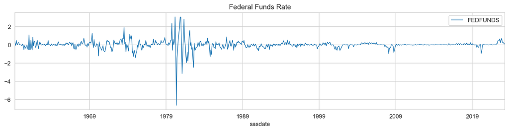

```python
# Actual Federal Funds Rates
fig, ax = plt.subplots(dpi=150, figsize=(15, 3))
Actual_Rate.plot(ax=ax, linewidth=1)
ax.set_title('Federal Funds Rate')
plt.show()
```

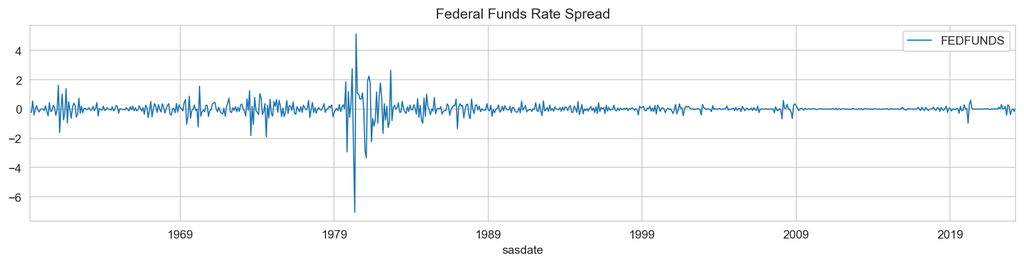

```python
# Interest rate spread
fig, ax = plt.subplots(dpi=150, figsize=(15, 3))
Rate_Spread.plot(ax=ax, linewidth=1)
ax.set_title('Federal Funds Rate Spread')
plt.show()
```